# 智能制造系统设计 · 第 1 讲：课程导论、工程与社会与质量工程（一）

刘训臣

山东科技大学 机械电子工程学院

# 第〇部分 · 课程介绍与本讲定位

- 本讲教学内容与主线（四个内容块各讲什么）
- 教学进度 · 10 次课全览
- 本讲在课程中的位置、考核方式与课程资源
- **主线**：国家战略 → 工程的社会属性 → 质量管理基础 → 质量背后的社会责任

## 教学进度 · 10 次课全览

| 次 | 模块 | 主题 |
| --- | --- | --- |
| **1** | **模块 1 与 3.1** | **课程导论、工程与社会与质量工程（一）：国家战略、工程的社会属性、质量管理基础** |
| 2 | 3.1 | 质量工程（二）与质量工具：五大工具 APQP／FMEA／MSA／SPC／PPAP、Cpk、QC 七大手法 |
| 3 | 3.2 | 工业工程与精益生产（＋实验 2 课时：线性规划与工业工程例子） |
| 4 | 3.3、3.4 | 安全工程与环保工程：海因里希法则、事故树 FTA、风险评估、三废治理、双碳 |
| 5 | 3.5、3.6 | 成本管理与人力资源：成本构成、投资回收期、NPV／IRR、质量成本、人才与激励 |
| 6 | 4.1～4.3 | 企业信息系统（一）：ERP、MES、PLM 与系统集成全景 |
| 7 | 4 | 企业信息系统（二）与 8D：CRM／WMS／APS，8D 八步与软件开发流程 |
| 8 | 工程与社会与工程伦理（一） | 工程事故与伦理准则：凯悦酒店、NSPE 准则、伦理决策框架 |
| 9 | 工程与社会与工程伦理（二） | 风险、安全与责任，工程师与组织：责任判定、组织文化与信任 |
| 10 | 工程与社会与工程伦理（三）与综合 | 技术的社会意义、国际化、AI 伦理；智能设计应用、前沿、课程设计与总复习 |

## 本讲在课程中的位置

**先修部分**（李勇老师主讲的理论基础）：图论 → 复杂网络 → 运筹学 → 数值分析 → 图像处理 → 深度学习。

**本段 10 次课**（本课程）：把方法落到制造系统上，回答三个问题：

1. **设计基础与目标**：质量、效率、安全、成本——企业的四个永恒主题（第 1～5 讲）
2. **设计对象**：ERP、MES、PLM、CRM、WMS、APS 等模块如何构成系统（第 6～7 讲）
3. **设计过程与责任**：8D 报告闭环 ＋ 工程伦理与社会责任（第 7～10 讲）

> 一句话：**理论部分回答“系统怎么建模”，本段回答“系统怎么设计、由谁负责”。**

## 课程资源与联系方式

**教材与参考书**

- 教材：李勇、刘训臣、韩善灵、高建刚《智能制造系统设计》（机械工业出版社；英文版 *Intelligent Manufacturing Engineering: Deep Operations Research*, Springer, 2026）
- 讲义：随每讲发布的自包含 HTML（课堂用 U 盘离线打开，无需联网）
- 参考资料：ISO 9001、IATF 16949、GJB 9001C 标准原文、五大核心工具手册、NSPE 伦理准则、AI 伦理风险分析报告等

**联系与获取**

- 主讲：刘训臣 邮箱：liuxunchen@sdust.edu.cn 电话：15800365152
- 课程网址：https://liuxunchen.github.io/xliu-group/zh/teaching/
- 答疑：课后或约定时间；课程设计分组指导

## 教材与参考书：读哪几本、怎么用

**主教材**（对应设计目标、设计对象、设计过程三部分）

- 中文版：李勇、刘训臣、韩善灵、高建刚《智能制造系统设计》，机械工业出版社，2025 年 3 月，ISBN 978-7-111-77617-8
- 英文版：*Intelligent Manufacturing Engineering: Deep Operations Research*，Springer，2026，ISBN 978-981-95-3108-0，DOI 10.1007/978-981-95-3109-7
- 两版六章一一对应：以中文版为主，英文版查术语与展开

**参考书与资料（4 类）**

1. AIAG 五大核心工具手册（APQP／FMEA／MSA／SPC／PPAP）——第 2 讲起
2. ISO 9001、IATF 16949、GJB 9001C 标准原文——查体系与认证条款（军标研制程序见第 2 讲拓展）
3. Harris 等《Engineering Ethics: Concepts and Cases》（5th ed.）与 NSPE 准则——第 8～10 讲
4. 《人工智能伦理风险分析报告》（2019）——第 10 讲
- 教材是主线、参考材料是深挖点：先读教材建框架，再按需查手册与标准
- 课程设计伦理分析章的素材，主要来自第 3、4 类材料

## 考核细则：考试、报告与课程设计

| 项目 | 形式 | 计量 | 说明 |
| --- | --- | --- | --- |
| 考试 | 3 次笔试 | 每次 100 分 | 概念、分析、计算，随课程进度安排 |
| 3 分钟报告 | 每次课一份 PPT | 计入考核 | 与实验报告一并作为平时成绩 |
| 课程设计 | 技术方案＋伦理分析章＋答辩 | 单独计分 | 第 10 讲布置与指导 |

- 考试题型（以智造 2021 A 卷为例）：单项选择 30 分、分析简答 30 分、论述与计算 40 分
- 质量部分的考点：五大工具、Cpk 判读、QC 七大手法、七项原则
- 报告与设计都是考核的组成部分，不是可选项

## 3 分钟 PPT 报告：每次课都交，三次指定题目

| 次序 | 题目 | 形式要求 | 评分点 |
| --- | --- | --- | --- |
| 第 1 次 | 图论在各人研究中的应用 | 4 页以内：问题—方法—矩阵—结论 | 问题定义清楚、矩阵建得对 |
| 第 2 次 | 手动计算神经网络 | 手算前向与反向传播，不用框架 | 步骤完整、数值正确 |
| 第 3 次 | 8D 报告 | 按 D1～D8 走完一个真实质量问题 | 原因分析有证据、D7 能防再发 |

- 3 分钟是硬约束：每次课都交，其中三次为指定题目（图论矩阵／手算神经网络／8D）；提前排练，宁少讲一个点，不超时
- 每次报告都要有“一张图”：矩阵、计算表或 8D 流程
- 讲清三件事：问题是什么、你做了什么、结论靠什么支撑

## 课程设计预告：伦理分析章怎么写

**课程设计 ＝ 一个制造系统的设计方案 ＋ 独立一章“伦理与社会影响分析” ＋ 答辩汇报。**

- 第 10 讲布置并分组指导，答辩时汇报伦理分析章
- 三步框架（第 10 讲给范例与评价标准）：
  1. **利益相关方与影响分析**：列名单（用户、操作工、维修工、下游客户、监管），写清各受什么影响、多大
  2. **伦理问题识别与定位**：把影响归入安全、隐私、公平、环境四类，指出最严重的一类
  3. **伦理决策与辩护**：做备选方案对比，用原则支持选择，并回应反对意见
- 写法要求：每个判断都要落到证据——数据、标准条款、事故调查报告
- 常见错误：写成“感想”，或者只批评企业、不给替代方案

## 课程地图：五个部分与 10 次课

**五个部分回答五个问题，10 次课按“目标 → 对象 → 过程 → 落地”递进。**

- **导论与伦理**（第 1、8～10 讲）：为什么学这门课、工程师为谁负责
- **设计目标**（第 1～5 讲）：质量、效率、安全、环保、成本、人——设计要达到什么
- **设计对象**（第 6～7 讲）：ERP、MES、PLM、CRM、WMS、APS——系统由什么构成
- **设计过程**（第 7 讲）：8D 与软件开发流程——出了问题怎么闭环
- **智能设计应用与前沿**（第 10 讲）：算法与模型怎么落到制造现场

> **每个部分结束时回看这一页：能不能用一句话回答它的问题？**
- 部分之间是判据关系：目标决定对象、对象决定过程；本讲负责导论与第一个目标——质量

## 学习目标：五条能力与验收标准

**课后逐条自检，能做到的打个勾；做不到的，用“推导留给 AI”页的问题补。**

- □ 能说出本讲四个内容块各自回答的问题：战略、社会、质量、责任
- □ 能用五个关键要素定义质量，并区分明确需求与隐含需求，各举一例
- □ 能说出质量管理三阶段的演进逻辑，以及“检验 → 预防 → 全面”的重心变化
- □ 能画出 PDCA 四阶段，并解释 A 阶段为什么最容易被忽视
- □ 能用一个真实案例说明“质量事故的代价是人”，并指出工程师的责任边界
- 五条对应本讲的四个内容块与课程主线，也是第一次 3 分钟报告的评分底稿
- 下次课抽查两条，抽查方式是“用自己的话讲 1 分钟”

## 本讲伦理与社会落点

**本讲把伦理问题第一次挂到具体场景上：**

- 工程师的能力不止于公式——**写作、表达、判断**都关系到工程安全（内容块 2）
- 工程是**社会实验**：有实验对象、结果不确定，工程师要为实验承担责任（内容块 2）
- 质量不是内部指标：**产品缺陷的代价是人**——凯悦酒店坍塌、737 MAX 停飞（内容块 4）
- 由此给出全课**伦理与社会主线**：技术讲到哪里，伦理问题就讨论到哪里（内容块 4）

**工程与社会与工程伦理 = 6 课时**：第 1 讲 1（本讲内容块 2、4）＋ 第 8 讲 2 ＋ 第 9 讲 2 ＋ 第 10 讲 1。

> **贯穿 10 次课的一句话：技术从来不是价值中立的，每个设计决策都会落到具体的人身上。**

## 本讲 90 分钟怎么安排

> **90 分钟 ＝ 开场 8 ＋ 讲授 72 ＋ 讨论 6 ＋ 小结 4。**

| 序 | 时间块 | 讲什么 | 分钟 |
| --- | --- | --- | --- |
| 0 | 开场与课程定位 | 定位、进度、考核与资源 | 8 |
| 1 | 内容块 1 · 时代背景 | 制造强国、中国制造 2025 | 18 |
| 2 | 内容块 2 · 工程与社会 | 社会属性、责任边界 | 18 |
| 3 | 内容块 3 · 质量管理 | 质量定义、七项原则、ISO | 22 |
| 4 | 内容块 4 · 社会责任 | 凯悦与 737 MAX、责任判定 | 14 |
| 5 | 例题与讨论 | 真题、讨论、计算例题 | 6 |
| 6 | 小结与下讲预告 | 小结、作业、第 2 讲预告 | 4 |

- 讲授 72 分钟、讨论与小结 10 分钟；内容块 3 最重（22 分钟），时间紧先压内容块 1（18 → 14 分钟），块 3、4 不压
- 内容块 3 里的标准体系 5 页各 30 秒（约 2.5 分钟）＋缩写速查 1 分钟（课后自查），约 3.5 分钟，从压缩内容块 1 得到的 4 分钟里出
- 例题页为课后精读，课上择讲 1～2 道

## 学习方法：预习、笔记、AI 提问与报告

| 环节 | 做什么 | 不要做什么 |
| --- | --- | --- |
| 课前预习 | 读教材对应章节（第 1 章、3.1 节），带一个具体问题进课堂 | 空手来、只听结论 |
| 课堂笔记 | 记结论 ＋ 一个例子 ＋ 自己的疑问 | 抄 PPT 原文 |
| 课后 AI 提问 | 用每讲末“推导留给 AI”页的问题查证、补全、质疑 | 把 AI 答案当标准答案 |
| 作业与报告 | 4 道题（概念／分析／应用／思考）；每次课 3 分钟 PPT 报告 | 临交前才动手 |

- 每讲用一页 A4 整理：**三句话 ＋ 一张图**——每讲“本讲小结”的三句话就是骨架
- 查证类问题交叉核对官方来源（标准原文、事故调查报告、教材），AI 用来找线索，不用来下定论
- 预习只需 20 分钟，但要在课前写下“我没看懂的那一个点”

## 推导留给 AI：课程介绍与本讲定位

- 用一句话概括：这门课的两个关键词为什么是“系统”和“设计”？
- 查证《中国制造 2025》的发布机构、发布时间与“三步走”目标，并说明它与二十大报告“新型工业化”的关系。
- 智能制造系统包含哪些模块？各自解决什么问题？用自己的话画一张模块关系图。
- 工程伦理与工程安全是什么关系？为什么质量工程师也要懂伦理？

## 产教融合 · 本讲企业真题：齿轮产线客诉与质量成本

> **企业场景：**某精密传动件企业齿轮/链轮产线近一个月客诉 37 起、返修成本 18.6 万元，客户要求 8 周内提交 8D 报告。

| 企业真实问题 | 本讲工具 | 学生产出 |
| --- | --- | --- |
| 客诉集中在齿面磕碰与啮合异响；返修成本高，预防投入低 | 质量三阶段、七项原则、质量成本四类 | 客诉排列图＋质量成本测算（作业 1） |

- **教案对应：**第三章 3.1 质量工程；**企业参与：**质量部提供脱敏客诉台账，工程师线上点评
- **验收：**客诉分类可统计；损失结构从“外部失败”转向“预防”，并给出 2 条改进建议。

# 第一部分 · 智能制造的时代背景与国家战略

- 制造业是实体经济的根基；中国制造 2025：十大重点领域与五项重大工程
- 智能制造的内涵与系统组成
- 二十大报告、新质生产力与新工科
- **主线**：方向（立足机械、赋能实体）→ 战略（制造强国）→ 系统（人机一体化智能系统）
- **承上**：本节课从这里开始正式讲内容（前面只交代课程定位）；本部分要回答“为什么必须做智能制造、国家战略怎么落到系统方法”。

## 制造业是实体经济的根基

- 制造业是**立国之本、强国之基**：没有强大的制造业，就没有国家和民族的强盛
- 制造业提供**就业、税收与技术溢出**，是科技创新最密集的应用场景
- 我国是制造大国，但**大而不强**：高端装备、核心零部件、工业软件仍受制于人
- 新一代人工智能蓬勃兴起，**要以智能制造为主攻方向**，推动产业迈向全球价值链中高端

> **选择比努力更重要：90 年代选建筑、00 年代选信息、10 年代选金融、20 年代选智能。**

## 中国制造 2025：主要内涵

**2015 年 5 月，国务院印发《中国制造 2025》——我国实施制造强国战略的第一个十年行动纲领。**

**四个转变**

- 要素驱动 → **创新驱动**
- 低成本优势 → **质量效益优势**
- 资源消耗粗放制造 → **绿色制造**
- 生产型制造 → **服务型制造**

**一条主线**：加快新一代信息技术与制造业深度融合 → **主攻方向**：推进智能制造（数字化、网络化、智能化）

**五条方针**：创新驱动、质量为先、绿色发展、结构优化、人才为本

## 智能制造的内涵：人机一体化智能系统

**智能制造（Intelligent Manufacturing）** 是由智能机器和人类专家共同组成的人机一体化智能系统：

- 在制造过程中能进行分析、推理、判断、构思和决策等智能活动
- 人与智能机器合作共事，**扩大、延伸甚至部分取代**人类专家的脑力劳动
- 把制造自动化的概念更新、扩展到**柔性化、智能化和高度集成化**
- 系统能不断充实知识库，具有**自学习**能力，能感知环境并规划自身行为

> 关键变化：从“自动化执行”到“**自主决策**”——这正是“智能”二字的落点。

## 智能制造系统的五个层次

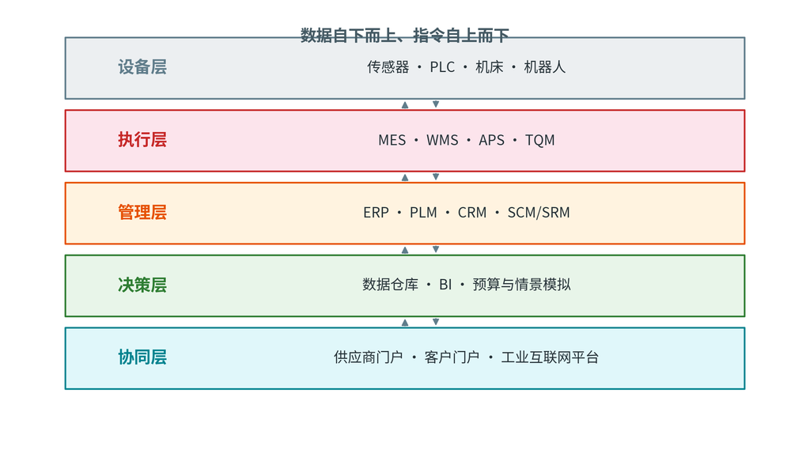

- 五层各管一段：设备层管动作、执行层管工单、管理层管资源、决策层管方向、协同层管边界
- 数据自下而上、指令自上而下——**同一件事只能有一种口径**
- APS 跨管理层与执行层：把计划翻译成工序时点
- 第 6、7 讲会逐个展开 ERP、MES、PLM、CRM、WMS、APS

## 从“产品”到“关系”：智能制造的思维转变

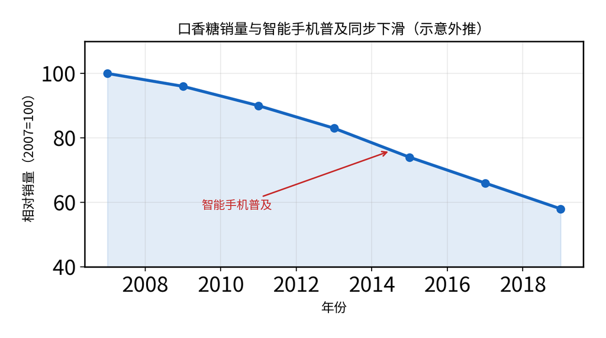

- 传统制造研究**事物的形状**：尺寸、公差、材料、工艺
- 智能制造研究**要素之间的关系**：订单—设备—质量—成本—人员之间的关联
- 例子：智能手机普及 → 排队看手机 → 口香糖销量下降——**看似无关的两个事物，数据里存在关系**
- 方法的基石是**图论**：把场景变成矩阵（邻接矩阵／权矩阵），再用网络与学习算法找规律

## 中国制造 2025 出台的国际背景

- **新一轮科技革命与产业变革**：新一代信息技术与制造业深度融合，催生新的生产方式、产业形态、商业模式和经济增长点；基于信息物理系统的智能装备、智能工厂正在引领制造方式变革
- **发达国家“再工业化”**：国际金融危机后，发达国家纷纷重塑制造业竞争新优势，加快推进新一轮全球贸易投资新格局
- **发展中国家加快承接**：积极承接产业及资本转移，拓展国际市场空间

| 外部变化 | 官方表述（国发〔2015〕28 号） | 对我国的含义 |
| --- | --- | --- |
| 技术侧 | 网络众包、协同设计、大规模个性化定制、精准供应链管理等正在重塑产业价值链 | 制造方式与商业模式同时被改写 |
| 竞争侧 | 发达国家“再工业化”＋发展中国家承接转移 | 面临“双向挤压” |
| 国内侧 | 大而不强：自主创新能力弱、关键核心技术对外依存度高 | 必须换发展方式 |

> 判断：新一轮科技革命和产业变革与我国加快转变经济发展方式形成**历史性交汇**。

## 十大重点领域（一）：信息技术与机床机器人

| 重点领域 | 官方重点方向 | 关键“卡点” | 与机械专业的关系 |
| --- | --- | --- | --- |
| 新一代信息技术产业 | 集成电路及专用装备、信息通信设备、操作系统及工业软件 | 核心通用芯片、高端工业软件 | 提供算力、软件与数据底座 |
| 高档数控机床 | 精密、高速、高效、柔性数控机床与基础制造装备及集成制造系统 | 高档数控系统、伺服电机、轴承、光栅等功能部件 | 机床是“装备母机”，机械专业主战场 |
| 机器人 | 工业机器人、特种机器人、服务机器人 | 本体、减速器、伺服电机、控制器、传感器与驱动器 | 机械＋控制＋感知的集大成 |

- **为什么排在最前**：信息技术给“大脑”，机床与机器人给“手脚”，两者共同决定制造系统的上限
- **与课程的关系**：精度、刚度、动力学与控制，正是力学、振动与噪声、控制工程的应用场景
- **记忆法**：十个领域＝信息、装备、航天、海洋、交通、汽车、电力、农机、材料、医药
- **提问**：一台五轴机床里，哪些是机械问题，哪些是控制问题，哪些是数据问题？

## 十大重点领域（二）：空天与海洋装备

| 重点领域 | 官方重点方向 | 关键瓶颈 | 与机械／本课程的关系 |
| --- | --- | --- | --- |
| 航空航天装备 | 大型飞机、宽体客机、重型直升机、干支线飞机、无人机；高推重比、先进涡桨（轴）与大涵道比涡扇发动机；新一代运载火箭、卫星、载人航天与深空探测 | 航空发动机、机载设备与系统 | 结构强度、振动与噪声、可靠性 |
| 海洋工程装备及高技术船舶 | 深海探测与资源开发装备、海上作业保障装备；深海空间站、大型浮式结构物；豪华邮轮、LNG 船 | 高技术船舶设计与总装 | 大型装备制造与系统集成 |

- 航空发动机被称为“工业皇冠上的明珠”：高温合金、叶片加工、转子动力学，一项都离不开机械
- 海洋装备的看点是**环境载荷**：深海高压、腐蚀、疲劳，直接决定结构与材料的选择
- 山东是海洋大省，海洋工程装备与高技术船舶是区域产业的重要方向
- 与课程呼应：第 4 讲安全工程讲失效与风险，正是这类装备的底线

## 十大重点领域（三）：交通、汽车与电力装备

| 重点领域 | 官方重点方向 | 机械专业落点 |
| --- | --- | --- |
| 先进轨道交通装备 | 体系化安全保障、节能环保、数字化智能化网络化技术；绿色智能、高速重载装备系统 | 转向架、牵引传动、制动与轮轨关系 |
| 节能与新能源汽车 | 电动汽车与燃料电池汽车；动力电池、驱动电机、高效内燃机、先进变速器、轻量化材料、智能控制 | 轻量化结构、电驱动总成、整车集成 |
| 电力装备 | 大型高效超净排放煤电机组、水电机组、核电机组、重型燃气轮机；新能源与储能装备、智能电网输变电设备 | 旋转机械、强度与振动、可靠性设计 |

- 三个领域的共同点：**大规模、高可靠、强监管**——一个零件失效就可能停掉一条线、一座站
- 新能源汽车是“机械＋电＋软件”的典型，本课程的信息系统模块正是它研发与生产的底座
- 轨道交通的“系统全寿命周期、整体解决方案”，会在第 5 讲成本管理（全生命周期成本）中再出现
- **提问**：为什么“节能”和“新能源”被放在同一个重点领域里？

## 十大重点领域（四）：农机、新材料与医疗器械

| 重点领域 | 官方重点方向 | 机械专业落点 |
| --- | --- | --- |
| 农机装备 | 粮棉油糖等大宗作物育、耕、种、管、收、运、贮装备；大型拖拉机及复式作业机具、大型高效联合收割机 | 结构设计、液压传动、智能决策与精准作业 |
| 新材料 | 特种金属功能材料、高性能结构材料、功能性高分子、特种无机非金属、先进复合材料；超导、纳米、石墨烯、生物基材料 | 材料—结构—工艺一体化；成形与加工 |
| 生物医药及高性能医疗器械 | 新机制新靶点化学药、抗体药物、新型疫苗；影像设备、医用机器人、全降解血管支架 | 精密机构、运动控制、人机交互与安全 |

- **三层记忆法**：信息与装备（第 1～8）→ 基础与材料（第 9）→ 民生与健康（第 10）
- 医疗器械的启发：同样是机械设计，**失效后果不同，设计准则就不同**——本课程“准则”二字的由来
- 农机＋智能＝精准农业：北斗导航、变量施肥、无人农机，是机械与信息交叉最直观的场景
- 一句话：十个领域有一条共同逻辑——先把“卡脖子”的环节列出来，再按技术路线图逐个攻

## 五项重大工程：创新中心到高端装备

| 重大工程 | 专栏主要目标（《中国制造 2025》） | 一句话理解 |
| --- | --- | --- |
| 国家制造业创新中心建设 | 2020 年形成 15 家左右、2025 年力争 40 家左右制造业创新中心（工业技术研究基地） | 补“关键共性技术”的空白 |
| 智能制造工程 | 试点示范项目运营成本、生产周期、不良品率：2020 年各降 30%，2025 年各降 50% | 换生产方式 |
| 工业强基 | 2020 年 40%、2025 年 70% 的核心基础零部件与关键基础材料实现自主保障 | 补工业底座 |
| 绿色制造 | 2020 年建成千家绿色示范工厂、百家绿色示范园区，重点行业主要污染物排放强度下降 20% | 给制造加绿色约束 |
| 高端装备创新 | 大型飞机、航空发动机及燃气轮机、核电装备、高档数控机床等一批创新和产业化专项 | 出标志性装备 |

- 五项工程是一条链：**创新中心给技术 → 智能制造给方式 → 工业强基给底座 → 绿色制造给约束 → 高端装备给出口**
- 与课程对应：工业强基落在质量与可靠性，绿色制造落在第 4 讲环保工程

## 三步走与 2020／2025 年主要指标

- **三步走**：2025 年迈入制造强国行列 → 2035 年达到世界制造强国阵营中等水平 → 新中国成立一百年进入世界制造强国前列
- 下表是《中国制造 2025》给出的**制造业主要指标**（国发〔2015〕28 号）：

| 类别 | 指标 | 2015 年 | 2020 年 | 2025 年 |
| --- | --- | --- | --- | --- |
| 创新能力 | 规模以上制造业研发经费内部支出占主营业务收入比重（%） | 0.95 | 1.26 | 1.68 |
| 创新能力 | 规模以上制造业每亿元主营业务收入有效发明专利数（件） | 0.44 | 0.70 | 1.10 |
| 质量效益 | 制造业质量竞争力指数 | 83.5 | 84.5 | 85.5 |
| 两化融合 | 宽带普及率（%） | 50 | 70 | 82 |
| 两化融合 | 数字化研发设计工具普及率（%） | 58 | 72 | 84 |
| 两化融合 | 关键工序数控化率（%） | 33 | 50 | 64 |

- **读表三条线**：投入（研发强度 0.95→1.68）、质量（竞争力指数 83.5→85.5）、数字化（关键工序数控化率 33→64）

## 二十大报告：六条部署逐条解读

| 报告部署（原文要点） | 关键词 | 对智能制造的意义 |
| --- | --- | --- |
| 着力实体经济、推进新型工业化 | 实体经济 | 制造业是实体经济的主体 |
| 建设“五个强国”与数字中国 | 制造强国、质量强国 | 制造与质量并列：本课程两条主线 |
| 产业基础再造与重大技术装备攻关 | 产业基础再造 | 对应工业强基，解“卡脖子” |
| 制造业高端化、智能化、绿色化 | 三化 | 智能化＝智能制造的主攻方向 |
| 战略性新兴产业融合集群发展 | 新增长引擎 | 新一代信息技术、人工智能、高端装备 |
| 数字经济与实体经济深度融合 | 数实融合 | 对应第 6、7 讲的 ERP／MES |

- 六条不是并列的口号，而是一条链：**实体经济（根）→ 新型工业化（路）→ 制造强国（标）**

## 2026 政策坐标：十五五、人工智能+ 与六大产业

> 上一页是二十大的部署；这一页把时间推到当下，看 2026 年的政策落点。
- 2026 年 3 月，十四届全国人大四次会议提出**六大新兴支柱产业**与**六大未来产业**
- 2026 年全面实施**“人工智能 +”行动**：从数字世界走向物理世界，智能经济核心产业规模已超万亿元
- 2026 年 9 月，全国先进制造业发展大会：以**新一代智能制造为主攻方向**，突出智能化、绿色化、融合化
- 外部对照：美国“没有后天”论——AI 竞争“不容失败”，传统硬实力让位于算力与算法

| 板块 | 产业清单 | 对智能制造的要求 |
| --- | --- | --- |
| 六大新兴支柱 | 集成电路、航空航天、生物医药、低空经济、新型储能、智能机器人 | 超精密产线、可追溯、多品种小批量 |
| 六大未来产业 | 量子科技、生物制造、绿色氢能与核聚变能、脑机接口、具身智能、6G | 场景与数据先行，装备与算法跟进 |

- 一句话：这十二个产业**都离不开智能制造**——产业链要装备与产线，人工智能要场景与数据；课程讲的方法就是底座的施工图

**结论：政策把智能制造从“一个方向”变成“十二个产业的共同底座”，这也是本课程的位置。**

## 新型工业化：五个内涵与一条路径

- 新型工业化道路的经典表述（党的十六大提出）：**坚持以信息化带动工业化，以工业化促进信息化**，走出一条“科技含量高、经济效益好、资源消耗低、环境污染少、人力资源优势得到充分发挥”的路子

| 五个内涵 | 通俗理解 | 智能制造中的抓手 |
| --- | --- | --- |
| 科技含量高 | 靠技术，不靠堆资源 | 研发强度、数字化研发设计工具、工业软件 |
| 经济效益好 | 同样投入产出更多 | 全员劳动生产率、MES 与 APS 提效 |
| 资源消耗低 | 单位产出少耗能、少耗材 | 绿色制造、能耗监测与优化 |
| 环境污染少 | 排放少、可循环 | 清洁生产、全生命周期绿色管理 |
| 人力资源优势得到充分发挥 | 不是简单“机器换人” | 人机一体化：经验变知识、知识变算法 |

- 二十大的定位：**“推进新型工业化”** 与建设制造强国写在同一句话里——新型工业化是路径，制造强国是目标
- 与智能制造的关系：数字化、网络化、智能化，正是“信息化带动工业化”的当代形态

## 新质生产力：三个特征与三个驱动

> **新质生产力**是创新起主导作用，摆脱传统经济增长方式、生产力发展路径，具有**高科技、高效能、高质量**特征，符合新发展理念的先进生产力质态。

| 特征 | 含义 | 智能制造中的表现 |
| --- | --- | --- |
| 高科技 | 由技术革命性突破驱动 | 图论、复杂网络、图神经网络进入制造系统 |
| 高效能 | 全要素生产率大幅提升 | 排产优化、质量预测、设备预测性维护 |
| 高质量 | 关键在质优 | SPC、FMEA、8D：用数据守住质量底线 |

- **三个驱动因素**：技术革命性突破、生产要素创新性配置、产业深度转型升级——三者共同“催生”新质生产力
- **基本内涵**：劳动者、劳动资料、劳动对象及其优化组合的跃升；数据成为新型生产要素
- **核心标志**：全要素生产率大幅提升；一句话记忆——**特点是创新，关键在质优，本质是先进生产力**
- 制造业落点：智能制造是发展新质生产力的主攻方向，本课程就是把“数据”变成“准则”

## 新工科与智能制造工程：能力矩阵

- 自 2019 年以来，全国已有 **315 所**高校开设智能制造工程专业（教材数据）；它是典型的“新工科”专业
- 培养逻辑一句话：**机械为本、智能为翼、系统为体、素养为基**

| 能力板块 | 能力要求 | 代表课程（本校培养方案） | 认证毕业要求 |
| --- | --- | --- | --- |
| 机械为本 | 力学、材料、工艺、精度 | 制图基础、机械制造技术、液压与气压传动、数控加工与编程技术 | 工程知识 |
| 智能为翼 | 感知、控制、算法、数据 | 电工电子技术、控制工程基础、工业物联网与大数据、嵌入式系统原理及应用 | 问题分析、使用现代工具 |
| 系统为体 | 建模、集成、运维 | 智能制造系统设计、智能工厂集成技术、智能生产系统与 CPS 建模、智能运维与健康管理 | 设计／开发解决方案 |
| 素养为基 | 工程与社会、团队、沟通 | 工程与社会与工程伦理、课程设计、生产实习 | 工程与社会、个人和团队、沟通、项目管理 |

- 本课程在这张矩阵里的位置：**系统为体**的主干课，同时承担**素养为基**中的工程与社会部分

## 智能制造成熟度与示范工厂

- **国家标准 GB/T 39116-2020《智能制造能力成熟度模型》**：5 个等级、4 个能力要素（人员、技术、资源、制造），给企业一把“自评的尺子”

| 等级 | 名称 | 能力特征 |
| --- | --- | --- |
| 一级 | 规划级 | 流程化管理，开始规划智能制造 |
| 二级 | 规范级 | 关键环节数字化，单点应用、规范管理 |
| 三级 | 集成级 | 跨系统、跨业务的网络化集成 |
| 四级 | 优化级 | 数据驱动的智能生产与优化 |
| 五级 | 引领级 | 产业链协同与模式创新，引领行业 |

- **国家目标**（《“十四五”智能制造发展规划》）：到 2025 年，70% 的规模以上制造业企业基本实现数字化网络化，建成 **500 个以上**智能制造示范工厂
- **教材数据**（截至 2023 年底）：国家级智能制造示范企业超过 **4300 家**——四部委 2187 家、工信部 1283 家、发改委 813 家、科技部 17 家
- **山东案例**：山东省智能制造示范企业超过 **4200 家**——省级 1161 家、数字经济“晨星工厂”2332 家、工业互联网标杆企业 183 家，另有其他类别

## 一条主线：目标—对象—过程—责任

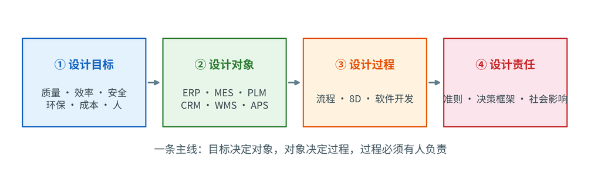

- **目标**：质量、效率、安全、环保、成本、人——设计要达到什么
- **对象**：ERP、MES、PLM、CRM、WMS、APS——系统由什么构成
- **过程**：流程、8D、软件开发——问题怎么闭环
- **责任**：职业准则、伦理决策框架、社会影响评估——谁来负责
- 判据：前一层是后一层的前提；考试分析题常跨层出

## 制造数据的价值链：从采集到决策

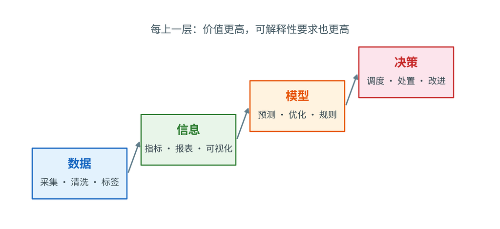

- **数据层**：传感器、PLC、业务系统——采集、清洗、打标签
- **信息层**：指标、报表、可视化——先统一口径
- **模型层**：预测、优化、规则——可解释性要求上升
- **决策层**：调度、处置、改进——必须有人对结果负责
- 常见断层：数据多、信息少、模型黑、决策难

## 课程知识地图：六个问题

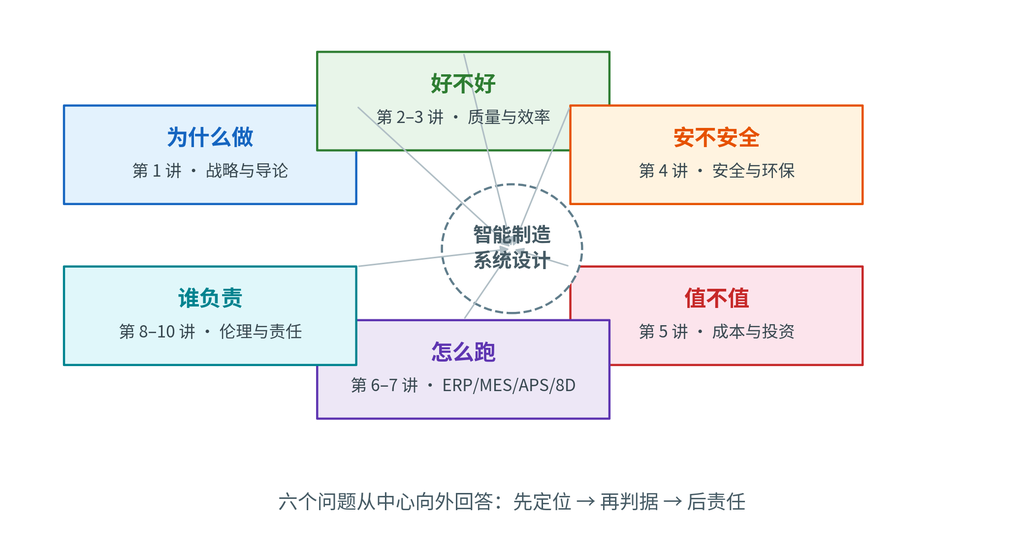

- 为什么做（第 1 讲）→ 好不好（第 2–3 讲）→ 安不安全（第 4 讲）
- 值不值（第 5 讲）→ 怎么跑（第 6–7 讲）→ 谁负责（第 8–10 讲）
- 六个问题由中心向外回答：**先定位，再判据，后责任**
- 考试：分析题常跨 2–3 个问题（如质量×成本、安全×效率）

## 排产为什么难：瓶颈与关键路径

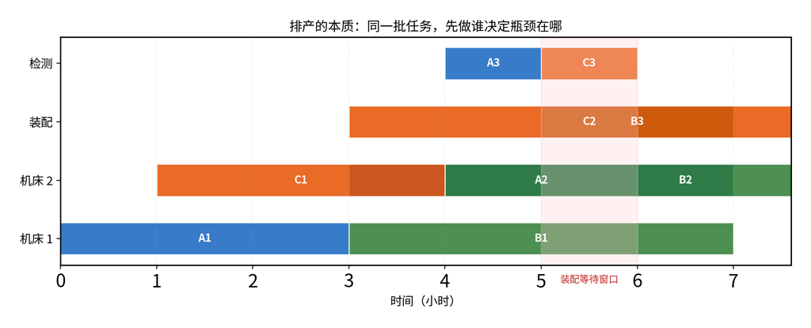

- 同样的任务、同样的设备，顺序不同，交期不同
- **瓶颈工序决定整条线产出**（木桶效应）；关键路径决定项目工期（最长路）
- APS 要同时满足设备、物料、人员、交期四类约束
- 排产是 NP 难问题：规模大时求“满意解”而非最优解

## 每个模块背后都有一类方法

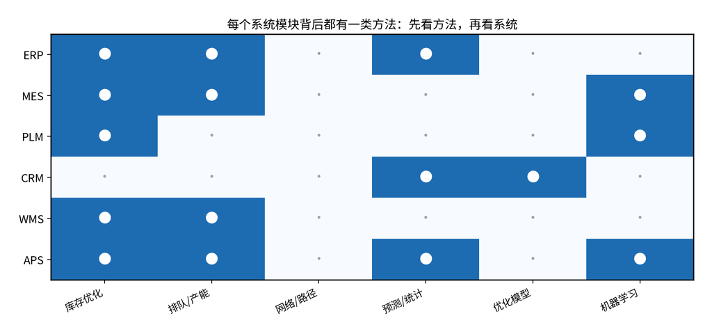

## 智能制造的三个判断标准

- **数据能否自动采集**：不是人工录入、不是事后补录
- **决策能否闭环**：不是报告完就结束，而是能触发动作
- **责任能否落到人**：不是“系统说的”，而是有人签字
- 三个标准缺一不可：只有数据是看板，只有决策是模型，只有责任是口号
- 用它们检查你实习的企业：处在哪个阶段？
- 注：**无人化不是智能制造的标志**（黑灯工厂只是少数场景）

## 为什么先讲设计目标

- 制造系统是为目标服务的：不考虑目标的“智能化”只是炫技
- 六个目标（质量、效率、安全、环保、成本、人）互相制约，取舍需要判据
- 本课程顺序：**目标 → 对象 → 过程 → 责任**——先有判据，再谈工具
- 第 2–5 讲逐个展开目标，第 6–7 讲展开对象与过程，第 8–10 讲解责任
- 提问：如果只能保留三个目标，你选哪三个？为什么？

## 常见误区：智能制造不等于无人化

- 误区一：**无人化＝智能化**（多数工厂仍是人机协同）
- 误区二：**上新系统＝智能化**（流程不变，系统只是把旧流程电子化）
- 误区三：**数据多＝智能**（没有指标与决策，数据只是负担）
- 误区四：**AI 万能**（模型需要数据、边界与验证）
- 正确理解：用数据与模型**增强**人的判断，而不是替代人的责任
- 判据：问三个问题——数据从哪来、决策谁做、责任谁担

## 从形状到关系：一张图看懂方法链

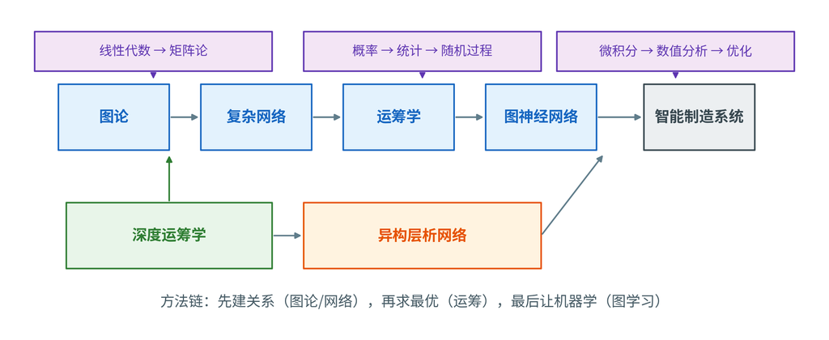

- 上半链：图论 → 复杂网络 → 运筹学 → 图神经网络（关系建模与学习）
- 下半链：深度运筹学 → 异构层析网络 → 智能制造系统（从方法到系统）
- 支撑：矩阵论、概率统计、微积分与优化——三条基础线托住整条方法链
- 判据：传统制造研究“形状”，智能制造研究“关系”；矩阵是两者的转换器

## 三个断层：数据、理论、经验

- **数据断层**：数据多但挖不出——缺指标与决策，停在“智能 Excel”
- **理论断层**：方法散装——课程是物理组合，缺系统关系的整体框架
- **经验断层**：创新困在产品本身——同质化竞争，忽视系统相互作用
- 共同答案：把制造系统当**关系网络**来研究（对应上一页的方法链）
- 提问：你实习的企业，三个断层各有多深？

## 深度运筹三步：把系统变成网络

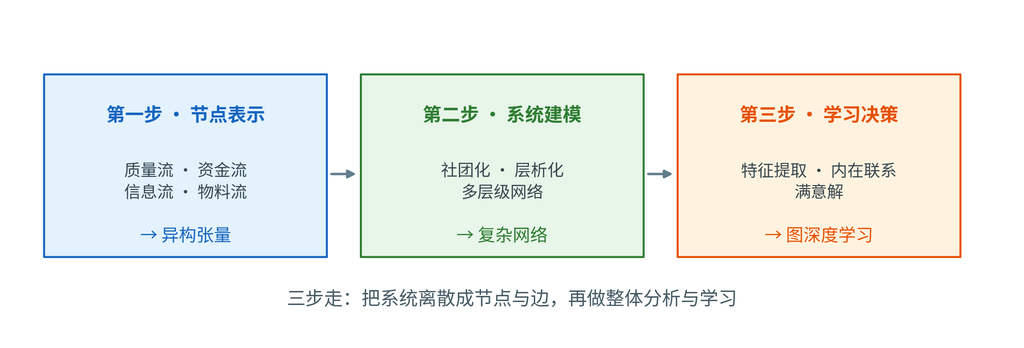

- 第一步 节点表示：质量流、资金流、信息流、物料流 → 异构张量
- 第二步 系统建模：社团化、层析化 → 多层级复杂网络
- 第三步 学习决策：图神经网络提取特征、寻找内在联系 → 求“满意解”
- 对照：有限元把结构离散成网格，深度运筹把系统离散成节点与边

## 六个设计要点：把系统当网络来建模

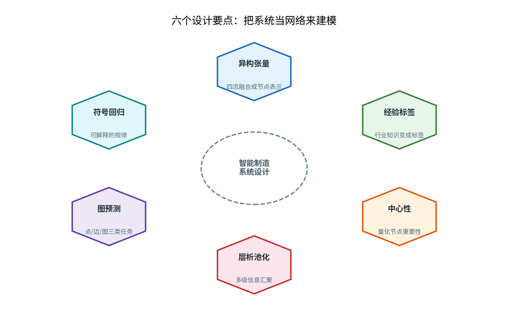

- 异构张量（四流融合）、经验标签（行业知识）、中心性（节点重要性）
- 层析池化（多级汇聚）、图预测（点/边/图）、符号回归（可解释规律）
- 用法：六个要点是**检查表**——设计智能系统时逐条问“用了哪条”

## 图论：把场景变成矩阵

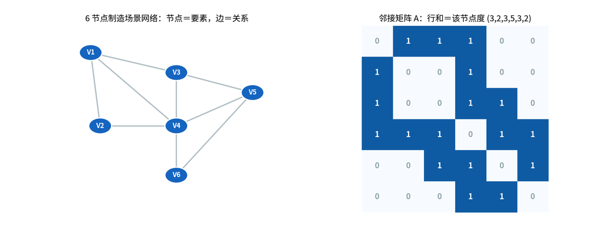

- 节点＝要素、边＝关系；场景先画成图，再写成**邻接矩阵**
- 邻接矩阵 $A$：行和＝该节点的度（图中 $d=(3,2,3,5,3,2)$，$V_4$ 最忙）
- 权矩阵 $W$：把 1 换成距离、时间或成本，用于最短路与关键路径
- 判据：能画图、能写矩阵、能读出度——三步都会，才算会“建模”

## 中心性：谁才是系统的关键节点

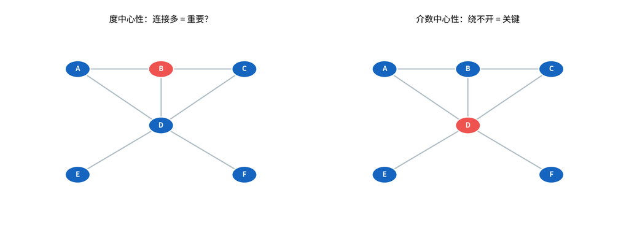

## 层析池化与图预测：多级信息汇聚

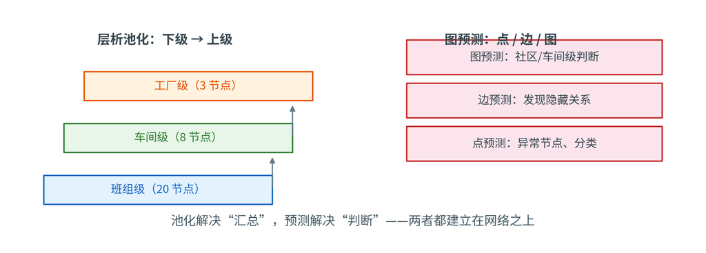

- 池化：班组级 → 车间级 → 工厂级逐级汇聚（对应班组/车间/厂的管理层级）
- 图预测三类：点预测（异常节点）、边预测（隐藏关系）、图预测（车间/社区判断）
- 判据：先有网络结构，再谈汇聚与预测——跳过网络直接上 AI 是空中楼阁

## 符号回归：从数据到可解释规律

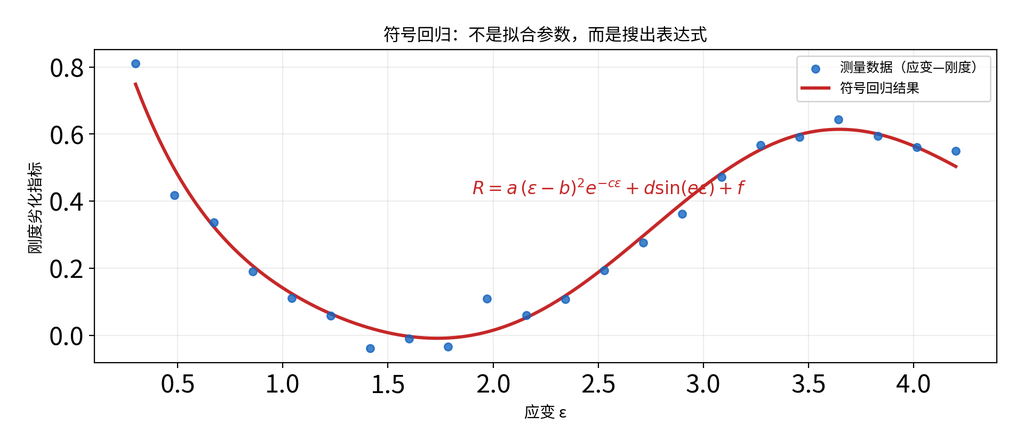

- 痛点：高次拟合看着好，换工况就失效（没有物理意义）
- 符号回归：从函数库搜索组合出**表达式**，而不是只调参数
- 教材案例：卡方项定形状、指数项抓趋势、常数项调基线
- 判据：能写进企业“准则”的，才是可解释的规律

## 设计基础的六个问题

- **方向**：立足机械、赋能实体——示范企业与产业数据
- **思维**：从设计产品到设计准则——关系比形状更重要
- **路径**：图论为基石——破圈法、邻接矩阵、权矩阵
- **逻辑**：运筹学十大分支——线性规划到决策分析，与系统模块几乎一一对应
- **智能**：六个设计要点——把系统当网络建模
- **内容**：设计目标、对象、过程、责任——全书五部分
- 用法：六个问题当复习索引，按“方向→思维→路径→逻辑→智能→内容”逐层回忆

## 第一部分小结：从国家战略到系统方法

1. **大势**：中国制造 2025 给出“三步走＋十大领域＋五项工程”——制造强国是跨越三十年的长期国策，不是一阵风
2. **方位**：二十大“新型工业化”、新质生产力、新工科——智能制造是主攻方向，也是这个专业与就业的方向
3. **方法**：从“研究形状”到“研究关系”——图论把场景变成矩阵，复杂网络与深度运筹再从矩阵里找准则
- 一条主线：**方向（立足机械、赋能实体）→ 战略（制造强国）→ 系统（人机一体化智能系统）**
- 一句话：选择智能制造就是选择国家战略；把关系变成矩阵，是这门课的第一个动作
- **思考题**：你所在实验室或实习企业的“节点”和“边”分别是什么？把它写成一张邻接矩阵——这就是第一次 3 分钟 PPT 报告
- **下一部分**：只懂技术还不够——工程师还要懂工程的社会属性（内容块 2）

## 推导留给 AI：时代背景与国家战略

# 第二部分 · 工程与社会导论

- 工程师能力需求的变化；工程作为社会实验
- 技术与社会相互塑造
- 隐私、知识产权与环境
- **主线**：工程不是“技术内部的事”，它的每个决策都嵌在社会之中
- **承上**：上一部分给了时代背景与国家战略；本部分要回答“工程为什么不是技术内部的事、工程师要对谁负责”。

## 工程师能力需求的变化

| 维度 | 现在 | 未来 |
| --- | --- | --- |
| 知识 | 基本认知、专业知识 | 跨学科知识、人文领域知识 |
| 能力 | 沟通、分析、问题解决 | 系统思维、跨界思考、数字建模、同理心、洞察力 |
| 价值观 | 尽善尽美、尽在掌控、追求成功 | 乐观韧性、拥抱变化、不惧失败 |
| 个性 | 严谨、专注、规避风险 | 尊重、开放、勇气 |

- 美国工程院的工程师画像：**专业知识**（工程与科学基础、技术能手、解决问题）＋ **职业技能**（沟通、伦理标准、批判性创新性思维、团队合作、跨学科、全球视野、系统思维）
- 现代工程要求**专业的深度 + 知识的宽度**，价值观与个性决定长期上限

## 工科生到底缺什么能力

- 课程调查的结论很直接：工科教育**重技术、轻人文**，短板不在专业课，而在“把事说清楚”与“把人搞明白”
- 外企 HR 协会的评语集中在两处：Outside-In（离市场太远）与 Inside-Out（讲不清自己）

| 短板 | 典型表现 | 课堂上的真实证据 |
| --- | --- | --- |
| 写作 | 词不达意、中英不对应 | 论文修改稿：中英题目不对应、摘要与 Abstract 不符、句子不完整 |
| 表达 | 复杂问题讲不简单 | “自己想说的别人听不懂”（Inside-Out） |
| 社交礼仪 | 邮件、会议、汇报不得体 | 课程调查：基本的社交礼仪问题普遍存在 |
| 工程判断 | 只看技术指标，不看人机料法环 | 2010 年上海“11·15”火灾：无证电焊、层层分包、抢工期 |

- 工程判断不是“经验多”，而是把技术、经济、法律、伦理放进同一个决策里

## 工程的定义：大英百科与判断力的艺术

> **大英百科**：工程是“应用科学原理将自然资源，以优化的方式转换成结构、机器、产品、系统及工艺，以造福人类的方法”。
- **知识**：以数学与自然科学为基础，但不是“科学的简单应用”
- **优化**：在约束下求最优，以最少的资源做出可靠有用的东西
- **判断**：工程是“需要判断力和常识的艺术”，公式替代不了判断

> **英文经典定义**（ECPD，后由 ABET 沿用）：…is **applied with judgment** to develop ways to utilize, **economically**, the materials and forces of nature **for the benefit of mankind**.
- 三个关键词：judgment（判断）、economically（经济）、benefit of mankind（造福人类）
- 词源：18 世纪欧洲的“工程”原指兵器制造等军事劳作，后扩展为民用

## 工程的六个特征与一个制造案例

- 统一案例：新能源汽车后底板“一体化压铸”——把几十个冲焊件压成一个零件，减重、减少焊点、缩短产线

| 特征 | 含义 | 案例中的体现 |
| --- | --- | --- |
| 目的性 | 从需求出发解决问题 | 续航焦虑 → 减重 → 一体化压铸 |
| 约束性 | 成本、工期、材料、标准、法规 | 材料流动性、模具寿命、压铸机吨位、碰撞法规 |
| 综合性 | 多学科、多利益方协同 | 材料、工艺、结构、热管理、维修与保险 |
| 创造性 | 没有现成答案，要自己构造并验证 | 免热处理铝合金、真空压铸、大件缺陷检测 |
| 风险性 | 一次性、难以完全预演 | 气孔与缩松不可全检，批次失效不可逆 |
| 社会性 | 嵌在社会之中，受价值观与政策塑造 | 不可修 → 维修经济性与保险定价之争 |

- 六个特征不是并列清单，而是**同一个决策的六个侧面**：减重越多，约束越紧，风险越集中

## 工程、科学与技术：三者如何区分

| 维度 | 科学 | 技术 | 工程 |
| --- | --- | --- | --- |
| 对象 | 自然规律 | 可复用的方法与工具 | 具体的人工物或系统 |
| 核心问题 | 为什么（解释） | 怎么做（手段） | 为谁做、在什么约束下做（求解） |
| 方法 | 观察、假说、实验 | 发明、试验、标准化 | 定义、设计、验证、权衡与类比 |
| 评价标准 | 可重复检验、解释力 | 有效、可靠、成本可控 | 满足需求且约束可行 |
| 典型产出 | 定律与论文 | 专利、工艺、标准 | 产品、产线、工程系统 |
| 失败的样子 | 被证伪 | 被替代 | 事故、延期、超支、社会不接受 |

- 冯·卡门：**科学家研究现有的世界，工程师创造从未有过的世界**
- 技术是工程的**实现手段**，也是科学通向工程的**桥梁**
- 一句话：科学是分析、发现，工程是综合、创造

## 工程作为社会实验：与临床试验的类比

- 社会实验的三个要素：**实验对象**（用户与公众）、**结果的不确定性**、**为实验承担责任**
- 与医学临床试验对照，工程缺的不是“难度”，而是**制度**

| 环节 | 医学临床试验 | 工程社会实验 | 差距 |
| --- | --- | --- | --- |
| 受试者 | 自愿报名、可随时退出 | 用户与公众，无法退出 | 没有“退出权” |
| 伦理审查 | 伦理委员会逐项审查 | 安全评估、环评，分散且偏事后 | 缺少独立审查 |
| 知情同意 | 签署知情同意书 | 用户协议、产品说明书 | 容易形式化 |
| 风险收益 | 预期获益大于风险才可开展 | 成本收益分析 | 价值判断被折算成成本 |
| 伤害补偿 | 试验伤害保险与补偿 | 产品责任与诉讼 | 补偿滞后 |

- 借过来的不是形式，而是三件事：**独立审查、真实告知、可以退出**

## 工程实验的特殊性：三处“不一样”

[figure not shown]

- **不可预演**：全尺寸无法试建，建成即“上线”，没有 I/II/III 期
- **公众不知情**：受试者不是报名者，也无法逐一取得同意
- **代价外部化**：失败成本由用户、居民、环境与后代承担
- **极端案例**：1986 年切尔诺贝利 4 号机组在安全试验中爆炸，约 5 万人次日撤离
- 医学是“先审批后做”，工程常常是“先做后补”
- 职业伦理、法规、公众参与三套制度必须同时在场

## 隐含契约：专业自治换公众安全

- 契约的两侧：社会让渡**专业地位、执业自治与准入**；工程师承诺**公众安全、健康与福祉优先**，并做到胜任、诚实、披露风险
- 为什么叫“隐含”：没有一纸合同，靠职业伦理与法律共同执行；违约可被追问——吊销执照、赔偿、除名
- 契约的不对称：公众看不懂工程，工程师必须先替公众想一步
- 义务的来源不是雇主，而是**职业身份**：签字即承担与专业判断匹配的责任
- **NSPE 总则**：工程是重要且需要学识的职业，服务“必须致力于保护公众的健康、安全与福祉”
- **第一条基本准则**：Hold paramount the safety, health, and welfare of the public（公众安全至上）
- 违约的代价：1981 年凯悦案，两名工程师被吊销执照，设计公司被剥夺资质

## 可预见性与可控制性：责任的边界

- **可预见性原则**：责任范围 $=$ 决策当时**可预见**的后果；预见能力依附于工程师的知识与经验
- **可控制性原则**：对**能够控制或影响**的决定与结果负责，不对完全无能为力的事负责
- 两条原则既**限制**责任（不无限扩大），也**界定**责任（不能以“我不知道”脱身）

| 可预见？ | 可控制？ | 责任判定 | 案例 |
| --- | --- | --- | --- |
| 已知 | 能控制 | 直接责任 | 福特 Pinto：工程师已建议加缓冲垫，公司决定不加 |
| 已知 | 不能控制 | 报告与披露义务 | 上级否决安全方案后，书面记录并越级报告 |
| 可合理推断 | 能控制 | 调查与验证义务 | 设计变更后必须回算并复核 |
| 不可预见 | 不可控制 | 不直接归责，但需持续追踪 | 纳米材料的长期健康效应 |

- 一句话：责任不是“背锅”，而是**该问的问题有没有问、该留的记录有没有留**

## 技术重塑社会：四次工业革命

| 阶段 | 技术内核 | 制造场景 | 社会重塑 |
| --- | --- | --- | --- |
| 工业 1.0 | 蒸汽机、水力 | 纺织机械、机床 | 工厂制度与产业工人 |
| 工业 2.0 | 电力、流水线 | 电气化产线、大批量生产 | 大规模消费与标准化 |
| 工业 3.0 | 计算机、数控 | CNC、柔性制造、工业机器人 | 全球供应链与信息社会 |
| 工业 4.0 | CPS、工业互联网、AI | 智能工厂、预测性维护 | 数据成为生产要素 |

- 节奏在加快：电动机从发明到应用约 65 年，无线电约 35 年，集成电路只用了 2 年
- 副作用滞后出现：隐私、就业结构、环境代价，往往要一代人才看得清
- 结论：技术改变的不只是效率，还有**人与人的关系模式**

## 社会选择技术：价值观如何决定路线

- 同一个技术问题通常有**多个可行解**，选哪个由社会与价值因素决定，而不由技术单独决定
- 哈里斯教材的例子：早期自行车有“高轮运动型”与“安全实用型”两条路线，社会最终选择了后者

| 议题 | 技术选项 | 社会如何选择 |
| --- | --- | --- |
| 新能源汽车 | 纯电、插混、氢能、合成燃料 | “双碳”目标与补贴牌照政策；欧盟立法确定 2035 年新车零排放 |
| 人脸识别 | 无感通行、刷脸支付 | “人脸识别第一案”与《个人信息保护法》第 26 条：公共场所采集受限 |
| 自动驾驶 | L2 辅助、L4 限定区域 | 德国 2021 年《自动驾驶法》、深圳 2022 年条例：先划区域与责任再放开 |

- 连“效率”本身也是社会定义的：童工曾被当作更“高效”的劳动力，被判定不道德后就不再计入效率

## 人本主义如何写进技术标准

- 两条评价线：**实用主义**看“是否使人福祉最大化”，**人本主义**看“是否尊重人的道德能动性”（人为贵）

| 价值 | 写进的标准或条款 | 对设计的要求 |
| --- | --- | --- |
| 安全 | GB 38031—2020：单体热失控后，电池系统 5 分钟内不起火、不爆炸；ISO 26262 划分 ASIL 等级 | 失效要能探测、能降级、能留逃生时间 |
| 隐私 | 《个人信息保护法》第 6 条最小必要、第 26 条公共场所采集限制 | 采集前先问“非采不可吗” |
| 公平 | 《个人信息保护法》第 24 条：自动化决策不得不合理差别待遇 | 算法结果可解释、可申诉 |

- 人本设计的五步：同理心 → 定义 → 头脑风暴 → 原型 → 测试（斯坦福 d.school）
- 标准不是“技术中立”的，它是**价值判断的可执行化**——写规范的人在做伦理决策

## 工程共同体的圈层与责任分配

| 角色 | 在系统中的位置 | 主要责任 | 常见失灵 |
| --- | --- | --- | --- |
| 工程师 | 技术判断与签章 | 对可预见的后果负责 | 以“按图施工”为由卸责 |
| 管理者 | 资源、进度、组织 | 安全投入与组织文化 | 压工期、模糊责任 |
| 工人/操作者 | 执行与报警 | 按规程操作、报告异常 | 违规操作、保持沉默 |
| 用户 | 使用与维护 | 按说明使用 | 擅自改装、超期使用 |
| 公众与监管 | 监督与立法 | 知情参与、制定标准 | 事后才介入 |

- 香港工程师学会行为守则的四项责任：对专业、对同事、对雇主或客户、**对公众**
- 哈里斯教材的“多手问题”：参与的人越多，个人越容易说“不是我一个人的责任”
- 责任分配原则：责任程度 $\propto$ 该成员本可阻止的程度——**不被共同体稀释，也不能只压给末端**

## 工程师职业的三个特征

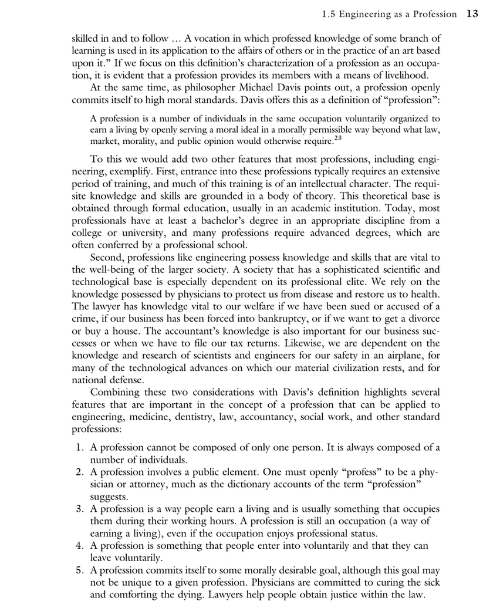

- **专业自治**：凭专业判断做决定，非技术人员不能以工程学理由推翻
- **准入与认证**：学历＋执照；工程教育认证（《华盛顿协议》）
- **伦理准则**：NSPE 第一条“公众安全优先”，中国机械工程学会规范
- 戴维斯：职业自愿组织起来、公开服务于某种道德理想，标准高于法律
- 与医生、律师同有“知识不对称＋信托责任”，但工程师还对上公众负责
- 只有技术没有自治是技术员，只有自治没有准则是行会

## 工程师的多重角色与责任边界

| 角色 | 主要工作 | 责任边界 | 典型冲突 |
| --- | --- | --- | --- |
| 设计者 | 方案、计算、图纸 | 对可预见的使用与误用负责 | 成本与安全的取舍 |
| 研究者 | 试验、数据、论文 | 数据真实、可重复、署名诚实 | 出成果压力与数据完整性 |
| 管理者 | 组织、资源、进度 | 不得用商业判断替代工程判断 | 工期与质量 |
| 顾问 | 评估与建议 | 忠于委托人，同时披露利益冲突 | 客户想听的话与事实 |
| 评审者 | 审查、签章 | 独立、回避利益冲突 | 人情与独立性 |

- 中国机械工程学会规范：只能签署**亲自准备或在直接监控下准备**的文件
- 同一人可能同时承担设计与评审两种角色——必须回避，否则责任边界失效
- 角色切换不是责任切换：在会议室里“摘掉工程师的帽子”，责任仍跟着人

## 隐私（一）：信息隐私与最小必要

- 隐私的实质是**控制**：控制“属于自己的东西”被谁知道、被知道多少、被用于什么（哈里斯）
- 信息隐私：个人对自身信息的控制权——工程中最常触碰的一类

| 采集场景 | 采集的数据 | 越界的信号 |
| --- | --- | --- |
| 员工考勤与门禁 | 人脸、定位、工时 | 用门禁数据推断病假与私人行程 |
| 工位监控 | 视频、动作识别 | 用“离岗时长”直接扣绩效 |
| 设备操作数据 | 账号、扫码、工艺参数 | 挪作非生产目的的分析 |
| 客户与订单信息 | 姓名、联系方式、采购记录 | 销售把客户名单带出公司 |

- 《个人信息保护法》三个抓手：第 6 条**最小必要**、第 13 条“人力资源管理所必需”、第 17 条**告知义务**；对比美国《隐私法》（Privacy Act 1974）只约束联邦行政机关
- 设计四问：非采不可吗？存多久？谁能看？能不能删？

## 隐私（二）：财产隐私与选择隐私

| 类型 | 保护对象 | 工程场景 | 越界的后果 |
| --- | --- | --- | --- |
| 财产隐私 | 薪酬、合同、报价、工艺数据 | 计件工资数据、供应商比价、客户订单 | 泄露即失去议价权与信任 |
| 选择隐私 | 自主决定个人事务的自由 | 算法排班、算法推荐、监控考核 | 被“数字泰勒制”支配，不敢行动 |

- 选择隐私的特别之处：信息不只是被看到，还会**被用来影响行为**——哈里斯说，掌握信息可以“胁迫”人，使其不敢行动
- 《个人信息保护法》第 24 条：自动化决策应透明、结果公平公正，不得不合理差别待遇；对权益有重大影响的，个人有权拒绝
- 财产隐私的常见坑：MES 里的工时与计件数据，既是工资依据也是绩效证据，权限设计不当就会外溢
- 工程上的边界：目的限定、比例原则、可解释、可申诉——四条缺一条，系统就滑向监控

## 知识产权：四种工具与制造业选择

| 工具 | 保护什么 | 期限与特点 | 制造业例子 |
| --- | --- | --- | --- |
| 专利 | 技术方案（发明/实用新型/外观设计） | 20/10/15 年，公开换保护 | 设备结构改进、控制方法 |
| 商业秘密 | 不为公众所知悉且采取了保密措施的信息 | 无期限，公开即失效 | 工艺配方、参数窗口 |
| 开源许可 | 软件的使用、修改与分发 | GPL 具传染性；MIT/Apache 宽松 | 工业软件与算法组件（SBOM） |
| 数据产权 | 数据资源与数据产品 | “三权分置”（数据二十条，2022） | 产线数据的归属写进合同 |

- 哈里斯的提醒：软件既像“作品”又像“发明”，版权只保护**表达**、不保护**思想**，所以软件保护至今是争议
- 工程师的日常规矩：署名与引用、不把公司数据带走、使用开源组件前查许可证义务（NSPE 第 9 条：把功劳归于应得之人）

## 环境：从排放到全生命周期

- 制造业的环境账：废气（VOCs、颗粒物）、废水、固废、噪声，还有 $\mathrm{CO_2}$ 这类没有围墙的排放
- 制度把约束**前置**：环评、“三同时”、排污许可、全国碳市场（2021 年 7 月启动，首批发电行业）
- “双碳”目标：2030 年前碳达峰、2060 年前碳中和（2020 年 9 月宣布）

| 分析尺度 | 要算的账 | 制造场景 |
| --- | --- | --- |
| 单个工序 | 能耗、排放、废弃物 | 涂装车间 VOC、热处理能耗 |
| 产品全生命周期 | LCA：从摇篮到坟墓 | 地毯与乙烯基地砖、纸杯与聚苯乙烯杯 |
| 企业与区域 | 碳足迹、碳配额 | 出口产品面临的碳关税压力 |

- 可持续发展的定义（布伦特兰报告）：满足当代需要，而不损害后代满足其需要的能力
- 工程决策的落点：把外部成本内部化——材料选择、能耗、可回收设计，都要在图纸阶段算清

## 知情同意：三个要件与工程难点

- 哈里斯的三个要件：**不受胁迫**（自愿）、**掌握相关信息**（知情）、**有理性与判断能力**（有能力）

| 要件 | 医学中的做法 | 工程中的难点 |
| --- | --- | --- |
| 自愿 | 受试者可拒绝、可随时退出 | 工人“没有别的选择”；用户被默认勾选 |
| 知情 | 知情同意书、风险逐项说明 | 产品复杂度高、信息过载、术语壁垒 |
| 有能力 | 评估受试者是否理解 | 公众面对群体风险，难以判断 |

- 市场交易不等于知情同意：买手机的人并不知道它可能爆炸（哈里斯）
- 难点在于集体风险无法逐一同意：若人人都有否决权，任何风险都无法接受——替代方案是**赔偿、交换与代表制**（听证、工会、监管）
- 康德的定言令式：任何时候都不能只把人当作手段，而必须同时当作目的

## 风险四维：评估、管理、认知、沟通

- 工程师的起手式：风险 $R = P \times C$，即发生概率与后果严重度的乘积

| 维度 | 要回答的问题 | 制造现场的例子 | 工具与做法 |
| --- | --- | --- | --- |
| 评估 | 风险有多大？ | 冲压线机械伤害、涂装 VOC | FMEA、故障树分析、ISO 12100 |
| 管理 | 多大风险可以接受？ | 检修周期与安全库存的取舍 | 成本收益分析、管理层决策 |
| 认知 | 人们如何理解风险？ | 老员工低估熟悉的噪声与粉尘 | 案例警示、风险感知调查 |
| 沟通 | 风险信息如何交换？ | 安全培训、警示标识、异常上报 | SDS、班前会、举报渠道 |

- 认知偏差有规律：公众对**自愿**风险的可接受度远高于非自愿风险（约 1000 倍）；工资每翻一倍，工人愿意承担的风险约增至 8 倍
- 评估永远有局限：无法预见所有失效模式，人为失误难预测，概率估计本身带主观性
- 工程师只做好“评估”是不够的——**风险是技术判断与价值判断的复合体**

## 案例：自动驾驶事故的责任分配

- 事实：2018 年 3 月，Uber 自动驾驶测试车在亚利桑那州坦佩撞死一名 49 岁行人，成为全球首例自动驾驶致行人死亡事故
- 美国国家运输安全委员会（NTSB）调查显示：系统在撞击前约 5.6 秒已探测到行人，但分类在“车辆—自行车—其他”之间反复跳变，紧急制动按设计未启用；安全员当时分心

| 环节 | 该问的问题（本讲概念） | 本例的答案 | 责任落点 |
| --- | --- | --- | --- |
| 感知与规划 | 行人横穿可预见吗？ | 属设计必须覆盖的场景 | 系统设计者 |
| 接管与监控 | 谁在控制？接管可行吗？ | 安全员分心，人机共驾的接管难题 | 运营方与监管 |
| 告知与同意 | 乘客与行人知情吗？ | 行人无从同意，宣传模糊了等级 | 企业与营销 |
| 测试管理 | 风险被评估与沟通了吗？ | 安全文化不足，测试许可被暂停 | 组织与管理层 |

- 多手问题：责任按“本可阻止的程度”分配到具体环节，而不是找一个人背锅
- 一句话：**可预见—可控制—被同意**，三问逐环节问一遍，责任就清楚了

## 工程师的写作与表达：让判断可被执行

**技术写作的判据只有一条：读者能不能据此做出你要的那个决定。**

| 文体 | 读者要什么 | 写法 |
| --- | --- | --- |
| 技术报告 | 结论、依据、风险、建议 | 结论先行，证据在后，风险单列 |
| 方案／请示 | 选哪个、为什么、要什么资源 | 给选项与代价，不给“都可以” |
| 邮件／纪要 | 谁、什么时候、做什么 | 一事一议，行动项带责任人与期限 |

- 四问自检：给谁看、要什么决定、凭什么、下一步做什么
- 三条硬判据：每个结论有出处；数字带单位与口径；不确定的地方写清不确定度，而不是写“大概”
- 常见毛病：只写过程不写结论；把“做了很多工作”当成果；中英术语不对应
- 一句话：**写得清楚，是工程判断的一部分**

## 工程技术交流：图纸、规范与邮件

**工程交流的三类载体，法律效力依次递减，但都不能“说过就算”。**

| 载体 | 它是什么 | 判据 |
| --- | --- | --- |
| 图纸 | 几何、公差、材料与技术要求，签章即责任 | 尺寸链闭合、基准明确、公差与工艺能力匹配、变更可追溯 |
| 规范／标准 | 引用“标准号 + 年份”，用“应／宜／可”分级 | 引用有效版本，不写“按相关标准”这种空话 |
| 邮件／纪要 | 决策与承诺的留痕 | 一事一议、结论在首段、抄送到位、附件带版本号 |

- 为什么：交流失误是事故的常见根因——凯悦的吊杆变更只靠电话，事后成了“谁同意的”之争
- 判据：任何一条技术要求，都要能回答“谁签的、依据哪版、改了有没有通知到执行的人”
- 一句话：**图纸和邮件，都是将来要拿出来给人看的东西**

## 工程决策中的不确定性：三类与三策

**不确定性不等于随机性：随机性有分布，不确定性里还有“我不知道”。**

| 类型 | 例子 | 对策 |
| --- | --- | --- |
| 参数不确定 | 材料强度、载荷、摩擦系数、来料波动 | 保守取值、安全系数、区间估计 |
| 模型不确定 | 简化假设、边界条件、仿真误差 | 试验标定、模型验证与确认、留裕度 |
| 情景不确定 | 需求变化、政策调整、竞争与替代 | 情景分析、冗余与可逆、分阶段决策 |

- 敏感性分析：先找出“哪个参数最要命”，再决定把钱花在哪个不确定上
- 判据：能不能说清最坏情况、可承受边界，以及“哪些是我不知道的”
- 与可靠性的分工：可靠性处理“规律已知的失效”，不确定性处理“连规律都不确定”的部分
- 一句话：**工程决策不是消除不确定性，而是让它可控、可承受、可回退**

## 工程伦理与法律：合法只是底线

**法律是社会的最低共识，伦理是专业共同体对自己的更高要求——两者之间那片灰色地带，才是工程师常站的地方。**

| 维度 | 法律 | 伦理 |
| --- | --- | --- |
| 来源 | 立法与行政机关 | 职业共同体、公众期待、专业准则 |
| 要求 | 最低限度，人人必须遵守 | 应然标准，往往高于法律 |
| 执行 | 国家强制力 | 同行评价、职业团体、良心与舆论 |
| 范围 | 有属地与时效 | 跨地域、跨代际 |

- 三种“合法但不合伦理”：利用规则漏洞、利用信息不对称、把伤害转移到看不见的人身上
- 例：达标排放但把污染留给下游；合同免责但隐瞒已知缺陷；合规裁员但违背承诺
- 顺序：伦理常常领先法律——自动驾驶、算法歧视都是先有伦理争论，后有规则
- 判据：把“会不会被罚”换成“如果这件事登在头版，我能不能解释得清”
- 一句话：**法律问你“会不会被罚”，伦理问你“该不该做”**

## 利益相关者沟通：先画图，再说话

**利益相关者 = 受决策影响的人 + 能影响决策的人；漏掉一个，后面就要返工。**

| 象限 | 特征 | 策略 |
| --- | --- | --- |
| 权力高、利益高 | 有否决权且切身相关 | 重点管理：一对一、早期介入、共同定方案 |
| 权力高、利益低 | 能卡住但不太关心 | 令其满意：定期汇报、守住合规底线 |
| 权力低、利益高 | 受影响最大、话语权小 | 随时告知：说明补偿与安置，给表达渠道 |
| 权力低、利益低 | 间接相关 | 监督：公开信息即可 |

- 制造场景：产线自动化改造——操作工、班组长、客户、监管部门、周边居民各有诉求
- 判据：能否列出“谁受益、谁受损、谁有否决权”，并给每个关键方配对接人、渠道与频次
- 常见失败：只跟出钱的人沟通，最后被有否决权的人卡住
- 一句话：**沟通不是通知，是把对方的约束提前变成自己的设计条件**

## 公众参与与听证：让反对意见进入设计

**公众参与不是程序负担，而是把“社会可接受性”提前测一遍。**

- 为什么必须做：知识不对称（专家懂风险、公众懂感受）加上风险分配不均（收益归企业、风险归社区），就会产生邻避效应
- 三种形式：公示与征求意见、座谈会与听证会、问卷调查与走访；我国环评公众参与办法规定了公示、意见听取与反馈处理
- 三条判据：信息充分（看得懂，不是贴一堆术语）、时点前置（方案未定就参与）、反馈闭环（每条意见有回应与理由）
- 失败模式：走过场、只公示不回应、拿“已批复”当挡箭牌、把反对者当“不明真相”
- 工程收益：早参与能改设计（改选址、改工艺、加监测），晚对抗只能改工期与预算
- 一句话：**反对意见越早进来，代价越小**

## 工程事故的媒体报道：三种归因框架

**同一场事故，媒体可以讲成技术故事、人性故事或组织故事——框架决定了公众追问的方向。**

| 框架 | 叙事重点 | 追问 | 风险 |
| --- | --- | --- | --- |
| 技术框架 | 设备、设计、材料缺陷 | 哪个零件失效 | 忽略管理与监管 |
| 人为框架 | 违章、失误、失职 | 谁操作错了 | 滑向“找替罪羊” |
| 组织框架 | 决策、文化、监管、成本压力 | 什么让错误变得合理 | 叙事复杂，传播力弱 |

- 读报道三问：消息源是谁（官方／企业／目击者／匿名）、数字有没有口径（死亡、失踪、受伤是否分开）、结论是调查结论还是记者推测
- 企业应对：首响要快、事实要准、承诺要可核查；“捂”和“甩”都会放大舆情
- 对工程师的提醒：舆论压力会扭曲技术决策——要么过度保守，要么掩盖问题
- 一句话：**舆论不是事实，但它是工程必须面对的社会条件**

## 工程师的职业发展路径：三条线与三道坎

**职业发展的刻度不是头衔，而是你能负责的系统的边界。**

| 阶段 | 解决的问题 | 判据 |
| --- | --- | --- |
| 初级 | 按规范把事做对 | 交付质量稳定、可复现 |
| 中级 | 在约束下做取舍 | 能说清代价与风险，能对上对外解释 |
| 高级 | 定义问题与规则 | 影响半径从工位扩到产线、工厂乃至行业 |

- 三条线：技术线（工程师 → 资深 → 专家／技术带头人）、管理线（主管 → 经理 → 总监）、复合线（技术 + 质量／项目／市场）
- 三道坎：从“做事”到“带人”、从“专精”到“系统”、从“执行”到“决策”
- 判据：你解决的问题，“影响半径”与“不确定性”是否在变大
- 能力底座：写作表达、跨部门协调、成本与法律意识——本讲反复出现的三项
- 一句话：**职业发展的本质，是你能负责的边界在扩大**

## 注册工程师制度：执照为什么存在

**执照是“专业自治换公众安全”的具体凭证：国家把判断权交给专业，专业用准入与惩戒对社会负责。**

- 制度四要素：认可学历 → 资格考试 → 实践经验 → 伦理与推荐；缺一项都不能独立执业
- 我国：注册结构工程师、注册建筑师、注册建造师、注册监理工程师、注册安全工程师、注册电气／公用设备／化工工程师等
- 美国 PE：FE 考试 → 四年经验 → PE 考试；英国 CEng：按工程理事会的能力标准认证
- 为什么要有：工程后果不可逆，公众无法判断专业能力，只能用执照做“信任代理”
- 判据：有签字权就有法律责任；执照可以被吊销——凯悦案中结构工程师被吊销执照、剥夺资质
- 一句话：**执照不是荣誉，是把责任写进名字里**

## 工程专业认证：华盛顿协议与实质等效

**认证的对象是“专业”不是“学校”，看的是毕业生能做什么，不是实验室有多少设备。**

- 华盛顿协议 1989 年签署，我国 2016 年成为正式成员；与悉尼协议（3 年制）、都柏林协议（2 年制）分属三个层次
- 核心词是“实质等效”：不要求课程一样，要求培养结果可比
- 12 项毕业要求：工程知识、问题分析、设计／开发解决方案、研究、使用现代工具、工程与社会、环境与可持续发展、职业规范、个人与团队、沟通、项目管理、终身学习
- 为什么：工程师资格互认的前提是教育质量可比；没有认证，学历就要逐个审
- 判据：认证看“产出”——课程目标是否支撑毕业要求，毕业要求是否有考核证据
- 注意：学位互认不等于执业许可，能否执业仍由各国注册制度决定
- 一句话：**认证证明这套培养方案能产出合格的人，不证明某个人合格**

## 工程创新与风险：越新越不确定

**创新不是冒险，是把不确定性算清楚之后再冒险。**

| 风险类型 | 问什么 | 对策 |
| --- | --- | --- |
| 技术风险 | 原理通不通、能不能稳定复现 | 原型验证、TRL 成熟度评估、加速寿命试验 |
| 市场风险 | 有没有人要、愿不愿付这个价 | 小批试销、灰度发布、可回退设计 |
| 合规与伦理风险 | 能不能用、该不该用 | 提前做合规与伦理审查，留否决点 |

- 成熟度：TRL 1—9，从原理到量产；跨级跳（实验室直接上量产）是事故高发区
- 三条对策：小步快跑（缩短反馈环）、冗余与降额（留裕度）、失效安全（坏了也不伤人）
- 反例：为赶首发压缩验证——737 MAX 的组织压力就是典型
- 判据：能不能说清“最坏会怎样、怎么回退、谁有权按下停止键”
- 一句话：**创新的上限由想象力决定，下限由风险控制决定**

## 工程文化差异：责任与证据链的差别

**文化差异不是礼貌问题，而是“谁有权签字、文件算不算数、出错追到谁”的差别。**

| 维度 | 一种倾向 | 另一种倾向 | 工程表现 |
| --- | --- | --- | --- |
| 权力距离 | 决策集中，等上级拍板 | 决策分散，工程师可定 | 变更审批链的长短 |
| 不确定性规避 | 靠标准与程序 | 靠经验与变通 | 图纸与作业指导书的刚性 |
| 个人／集体 | 责任到人、签字负责 | 责任到团队、集体决策 | 出事后的追责方式 |
| 长期导向 | 看全生命周期成本 | 看当期成本与进度 | 选材、维护与冗余 |

- 跨文化合作先问三件事：谁有权签字、文件是否有法律效力、出错后追到谁
- 不要过度概括：文化差异是统计倾向，不能当个体标签；同一国家内部差异往往更大
- 判据：合同与规范里把“谁批、谁验、谁赔”写清楚，比揣摩文化更有效
- 一句话：**把责任写清楚，是最好的跨文化沟通**

## 本部分小结：工程不是技术内部的事

1. **工程的目标与约束由社会定义**：六个特征、社会实验、隐含契约都指向同一件事——技术可行不等于工程可行
2. **责任按“预见—控制—角色”分解**：可预见与可控制两原则、共同体与多手问题，让责任边界清晰，而不是被稀释
3. **社会政策是设计输入**：隐私、知识产权、环境、知情同意、风险四维，都要写进需求与规范，而不是事后补救

| 结论 | 本部分的依据 | 后续在哪里展开 |
| --- | --- | --- |
| 工程嵌在社会之中 | 六特征、社会实验、隐含契约 | 第 8 讲 工程事故与伦理准则 |
| 责任可分解、可追问 | 两原则、共同体、多手问题 | 第 9 讲 风险、安全与责任 |
| 社会政策是设计输入 | 隐私、知识产权、环境、知情同意 | 第 10 讲 技术的社会意义与 AI 伦理 |

> 工程的专业性，不只在“能做成”，更在“愿意为技术的后果负责”。

## 推导留给 AI：工程与社会

- 用“实验对象—不确定性—责任”三要素，分析一个你熟悉的工程（桥梁、汽车、软件系统均可）。
- 工程的社会实验与医学临床试验有哪些可比之处？知情同意如何落实？
- 举一个“社会价值观选择技术路线”的例子，并说明工程师在其中的角色。
- 信息隐私、财产隐私、选择隐私在智能制造系统里各对应哪些数据？
- 如果你负责一条产线的数据采集，如何做到“最小必要”？

# 第三部分 · 质量管理基础

- 质量的定义与五个关键要素；产品、顾客、供方与过程
- 质量管理的目标、原则、策划与控制
- 标准与体系：ISO 系列全景、ISO 9001 十章结构、IATF 16949 加严版
- **主线**：明确需求 → 过程控制 → 体系保证 → 持续改进
- **承上**：上一部分讲工程的社会属性；本部分要回答“质量怎么从口号变成可测量、可管理的体系”。

## 质量观念的四次演进：从挑出坏品到经营质量

| 阶段 | 时间 | 标志与方法 | 一句话质量观 |
| --- | --- | --- | --- |
| 质量检验 | 手工业时代起 | 专职检验、全检与抽检分选 | 质量是检验出来的 |
| 统计质量控制 | 1920s—1940s | 休哈特控制图、抽样检验 | 质量是生产出来的 |
| 全面质量管理 | 1960s 起 | 全员参与、人机料法环、ISO 9001 | 质量是管理出来的 |
| 六西格玛与卓越绩效 | 1980s 至今 | DMAIC、3.4 ppm、卓越绩效评价准则 | 质量是经营出来的 |

- 演进主线：**检验 → 预防 → 全员 → 经营**，每一次都是把质量防线前移
- 后一阶段不否定前一阶段：今天的工厂里四种质量观念同时并存
- 六西格玛的 3.4 ppm 是“6σ 能力＋1.5σ 长期漂移”的工程口径（第 2 讲推导）

## 质量定义的拆解：固有特性与赋予特性

> 上一页讲质量观念的演进；这一页回答：质量到底指产品的哪些特性。

**质量**：产品的固有特性满足顾客明确或隐含需求的程度；可以被衡量的只有“固有特性”。

| 特性类型 | 含义 | 制造场景例子 | 是否衡量质量 |
| --- | --- | --- | --- |
| 固有特性 | 产品自身具有、可测量或可感知 | 尺寸、硬度、续航、响应时间 | 是 |
| 赋予特性 | 由外部赋予、与产品本身无关 | 价格、交付期、保修条款 | 否 |

- 公差、性能与可靠性属于固有特性，可以直接测量；价格与交期是合同要求，不属于质量。
- 现场判断口诀：换一家供应商也能同样给出的，多半是赋予特性。
- 满足需求有程度之分，不是“合格／不合格”的 0-1 判断，第 2 讲会用 ppm 把它量化。

**记住：衡量质量只看固有特性；价格与交期再重要，也是合同问题，不是质量。**

## 质量五要素（一）：本质、品质与固有属性

五要素不是并列清单，而是回答五个不同问题的“质量追问框架”。

| 要素 | 回答的问题 | 制造场景的追问 | 常见误判 |
| --- | --- | --- | --- |
| ① 本质 | 质量到底是什么？ | 客户买的是哪种能力？ | 把参数高当质量好 |
| ② 品质 | 功能与性能如何？ | 哪些指标能写进规格书？ | 只看外观，忽略可靠性 |
| ③ 固有属性 | 哪些特性是产品自身具有的？ | 设计给了哪些可测量特性？ | 把价格、交期当质量 |

- 本质回答“为什么买”，品质回答“买到什么”，固有属性回答“凭什么衡量”
- 固有属性由设计赋予，因此“质量是设计出来的，而不是制造出来的”（教材）

## 质量五要素（二）：满足需求与实现需求的潜能

满足需求是底线，潜能是上限：前者决定“合格”，后者决定“期待”。

| 要素 | 回答的问题 | 制造场景的追问 | 常见误判 |
| --- | --- | --- | --- |
| ④ 满足既定需求 | 合同、标准、法规都满足了吗？ | 三条线分别由谁确认？ | 把自检合格当满足需求 |
| ⑤ 实现需求的潜能 | 能超越当前期望吗？ | 预留余量、可升级、可回收？ | 只满足今天，不管明天 |

- 满足需求是底线，潜能是上限：教材要求把环保与可持续发展纳入质量定义
- 潜能要在设计中预留：接口余量、可维护性、可回收性都要写进设计输入
- 五要素关系：本质是目的、品质是载体、固有属性是依据、满足需求是基准、潜能是未来

## 明确需求：合同、图纸与标准三条线

明确需求写在文件里、有法律约束力；关键是把文件语言翻译成可测量的质量特性。

| 载体 | 典型内容 | 转化为 | 确认人 |
| --- | --- | --- | --- |
| 合同 | 交付期、批量、退赔条款 | 里程碑与考核指标 | 销售＋项目经理 |
| 图纸与技术协议 | 公差、材料、性能、特殊特性 | 可测量的质量特性 | 设计＋质量工程师 |
| 标准与法规 | ISO 9001、IATF 16949、3C | 认证与型式试验要求 | 体系工程师 |

- 制造场景的三类硬要求：**公差**（如 ±0.02 mm）、**交付期**（如 30 天）、**认证**（3C／IATF 16949）
- 明确需求有三个特征：有法律约束力、可追溯到文件、可测量验证
- 最常见的漏点：合同写了交付期，图纸却没写包装与运输要求

## 隐含需求：用户预期与行业惯例

隐含需求不在合同里，却决定顾客“觉得好不好”；它靠工程判断和历史数据识别。

| 来源 | 典型隐含需求 | 识别方法 |
| --- | --- | --- |
| 用户预期 | 不会起火、不会突然停机、容易打开 | 客户走访、投诉与退货分析 |
| 使用场景 | 高温、潮湿、误操作、儿童接触 | 现场观察、同类产品失效库 |
| 行业惯例 | 防锈包装、备件长期可得、接口兼容 | 竞品拆解、标准与法规前瞻 |
| 法规趋势 | 环保标识、可回收、数据安全 | 法规跟踪、行业预警 |

- **隐含需求一旦成为行业惯例，就会变成标准或法规**：今天的惯例是明天的明确需求
- “容易打开”既是易用性，也是包装安全（儿童误触、运输破损）

## 需求识别失败的代价：三个真实案例

| 案例 | 未识别的需求 | 代价 | 今天的控制点 |
| --- | --- | --- | --- |
| 三星 Note 7（2016） | 电池在极端情况下不起火 | 全球召回后停产 | 供方变更审批、电池安全标准 |
| 强生泰诺（1982） | 药品从出厂到服用不被动手脚 | 7 人死亡、召回约 3100 万瓶 | 防篡改包装成为行业惯例 |
| 丰田“刹车门”（2009—2010） | 顾客投诉要被快速听见并处理 | 召回逾 800 万辆、品牌受损 | VOC 快速响应、召回管理 |

- 三个案例分别对应**设计变更、包装、服务响应**三类漏点
- 共同教训：需求识别不是“合同评审一次”，而是贯穿设计、采购、售后的持续活动

## 顾客与供方：外部顾客与内部顾客

质量发生在“供方—过程—顾客”的链条上，链条上的每一对交接都是一次质量承诺。

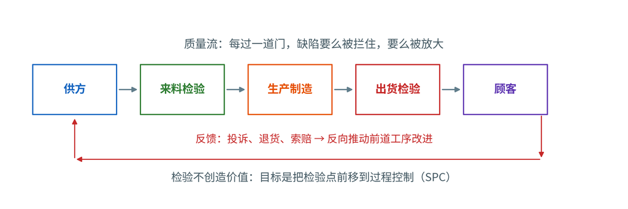

## 过程三要素：输入、活动与输出

质量产生在过程里，不在检验台上：把每个过程管住，质量自然稳定。

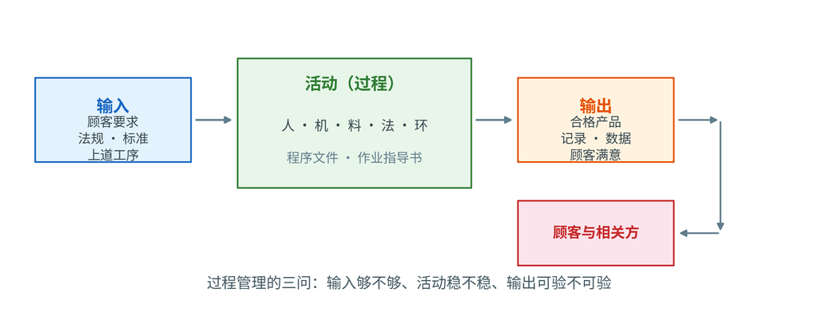

## 四类通用产品与质量控制方法

| 产品类别 | 质量控制重点 | 主要控制方法 | 典型工具 |
| --- | --- | --- | --- |
| 服务 | 响应、一致性、态度 | 服务流程标准化、顾客反馈 | 满意度调查、投诉分析 |
| 软件 | 功能正确、可靠、可维护 | 需求评审、测试、版本控制 | 单元测试、静态分析、FMEA |
| 硬件 | 尺寸、性能、寿命、安全 | 首件、巡检、终检、型式试验 | 卡尺／三坐标、SPC、可靠性试验 |
| 流程性材料 | 均匀性、批次一致性 | 配方与参数控制、批次留样 | 在线检测、直方图、批次追溯 |

- 同一家企业常同时交付四类产品：设备、控制软件、安装服务、耗材
- 方法选择原则：**能测量的就测，测不了的就管过程与流程**

## 五项活动的关系：一个闭环而非五件事

- ① 制定质量方针与目标：定方向——为什么做质量
- ② 质量策划：定路径、资源与节点——怎么做，**指导后三项活动**
- ③ 质量控制：现场监视与纠偏——做到没有不合格
- ④ 质量保证：面向顾客与合同提供信任——证明做得到
- ⑤ 质量改进：提升满足要求的能力——做得更好，结果回到策划
- 结构：策划在上，控制与保证一内一外，改进回到策划，形成 PDCA 大循环
- 例：新车型项目先定目标与策划，再控制试制过程、向主机厂提交 PPAP，量产后持续改进

> 五项活动不是五个部门，而是一条从“定方向”到“做得更好”的责任链。

## 质量策划：设计决定质量上限

质量策划是五项活动里最容易被跳过的一项：它决定质量上限，制造只能逼近上限。

- **质量策划**：制定质量目标，并规定必要的运行过程和相关资源（教材定义）
- 三方面内容：产品策划（识别与分类质量特性）、管理与作业策划、编制质量计划与改进规定
- 教材观点：**产品质量是设计出来的，而不是制造出来的**
- APQP 是质量策划的结构化形态：阶段＋交付物＋评审，把“说清楚”变成“做得到”（第 2 讲展开）
- 策划的产物不是文件，而是被执行的节点、责任人与资源
- 常见失败：策划只写目标不配资源，评审只签字不看风险

## 质量方针与目标：可测量、可分解、可考核

方针是方向，目标是可算的承诺；目标必须逐层分解到能考核的岗位。

| 层级 | 目标示例 | 数据来源（周期） | 责任人 |
| --- | --- | --- | --- |
| 公司级 | 顾客满意度 ≥ 95 分 | 满意度调查（年度） | 总经理 |
| 工厂级 | 直通率 ≥ 93%、零公里 PPM ≤ 50 | MES 与售后系统（月度） | 厂长 |
| 工序级 | 关键特性 $C_{pk} \ge 1.33$ | SPC 与检验记录（周） | 工序长 |
| 岗位级 | 首件确认执行率 100% | 首件记录（每班） | 班组长 |

- 可测量：有指标、有数据来源、有统计周期；可分解：公司→工厂→工序→岗位
- 可考核：与责任人和奖惩挂钩；警惕“指标游戏”，只考核结果会诱发瞒报

## 三阶段再审视：叠加而非替代

| 阶段 | 谁对质量负责 | 质量在哪里产生 | 判定依据 |
| --- | --- | --- | --- |
| 质量检验 | 检验员 | 成品端（事后） | 合格／不合格 |
| 统计质量控制 | 质量工程师 | 工序参数（事中） | 控制图与抽样 |
| 全面质量管理 | 全员与最高管理者 | 全流程与体系（事前） | 体系审核与顾客满意 |

- 演进主线：**责任从检验员转移到全员，防线从成品前移到设计**
- 三阶段是叠加不是替代：今天的工厂同时有来料检验、SPC 控制图与体系审核
- 为什么仍要检验：过程能力不足、来料波动、法规强制、破坏性试验只能抽检；检验的价值已从“挑坏品”转为“提供数据”

## 人机料法环：五要素的现场影响与控制

| 要素 | 典型失效来源 | 控制手段 | 记录／证据 |
| --- | --- | --- | --- |
| 人 | 技能不足、疲劳、违规操作 | 培训认证、首件确认、防错 | 培训记录、首件单 |
| 机 | 精度衰减、保养缺失、参数漂移 | 点检保养、参数监控、备件管理 | 点检表、设备履历 |
| 料 | 批次波动、混料、来料超差 | 来料检验、批次追溯、供方管理 | 检验报告、批次卡 |
| 法 | 文件缺失、参数错误、变更失控 | 作业指导书、变更管理、跨职能评审 | 工艺文件、变更单 |
| 环 | 温湿度、粉尘、照明、振动 | 环境监控、5S、防静电 | 环境记录、巡检表 |

- 人的特殊性：其他四要素由人操作，人又受管理影响——“人核心”不是口号
- 五要素既是鱼骨图的五支主干，也是现场审核的检查清单

## 五要素的现场应用：鱼骨图五支主干

鱼骨图是把五要素从一份「清单」变成一件「诊断工具」的那一步——先把结果写在鱼头，再沿五支主干逐层找原因。

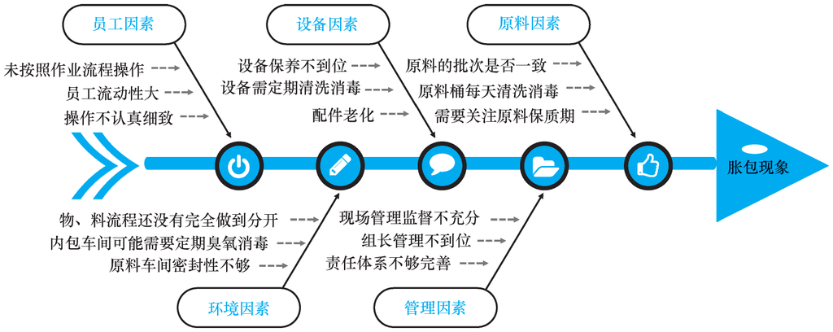

- 鱼骨图（石川图）把“结果”放鱼头，把“原因”按五支主干逐层展开
- 制造现场主干多用**人机料法环**；图中示例为员工、设备、原料、环境、管理
- 画法：定问题 → 画五支主干 → 头脑风暴填中层 → 拆到底层可行动的末端
- 三条纪律：末端要能采取措施、原因要现场验证、结论要用数据确认
- 第 2 讲展开画法与案例，第 3 讲在工业工程场景复现

## 质量文化：一把手工程与全员参与

| 层次 | 内容 | 落地载体 |
| --- | --- | --- |
| 精神层 | 质量方针、价值观、零缺陷意识 | 方针发布、质量月、案例教育 |
| 制度层 | 体系文件、考核与奖惩、变更管理 | ISO 9001 文件、质量责任制 |
| 物质层 | 设备、工装、检测手段、现场标识 | 5S、目视化、防错装置 |

- **一把手工程**：领导者的四个角色——支持者、决策者、推动者、服务者（教材）
- **全员参与**：三个条件——胜任（能力）、授权（权限）、参与（改进建议）
- 文化的检验标准：员工发现问题敢不敢停线、敢不敢报

## 质量成本四类：钱花在哪个环节

| 类型 | 典型科目 | 发生环节 | 计量特点 |
| --- | --- | --- | --- |
| 预防成本 | 培训、FMEA、供方开发、设计评审 | 设计与采购 | 主动投入、易预算 |
| 鉴定成本 | 来料／过程／终检、试验、MSA | 生产与交付前 | 随检验频次上升 |
| 内部损失 | 返工、报废、停线、复检 | 交付前（厂内） | 易统计、常被隐藏 |
| 外部损失 | 索赔、召回、运费、信誉损失 | 交付后（顾客处） | 难计量、放大效应 |

- 质量成本不是财务账上的一个科目，而是按质量活动归集的成本集合
- 越靠后发生，单位成本越高：预防 1 元 → 发现 10 元 → 流出 100 元
- 外部损失中的品牌与安全代价往往无法用钱衡量（第 4 部分伦理主线）

## 质量成本优化：1-10-100 与最佳质量水平

质量成本管理的目标不是把某类成本压到最低，而是让总成本与风险最小。

- 1-10-100 法则：同一缺陷，预防花 $1$ 元、检验发现花 $10$ 元、流出到顾客花 $100$ 元
- 例：100 件缺陷，预防阶段拦住约 100 元，靠检验拦住约 1000 元，流出则约 10000 元
- 最佳质量水平：预防＋鉴定成本随质量水平上升，损失成本下降，总成本在某点最低
- 曲线为相对值示意，不对应具体企业数据；现实中最佳点在很高合格率区间
- 外部损失无法完全货币化，最优决策要加上安全与信誉约束

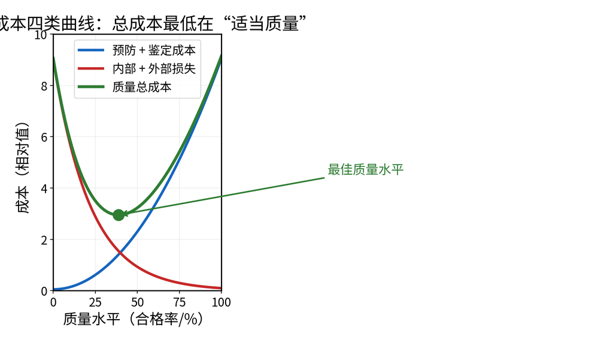

## 小结：从质量定义到质量体系

- **定义**：质量＝固有特性满足明确与隐含需求的程度——需求识别是一切质量活动的起点
- **过程**：质量产生于“输入—活动—输出”的链条，控制点要放进过程，而不是只放在成品端
- **体系**：方针目标 → 策划 → 控制 → 保证 → 改进的闭环，用人机料法环落地、用质量成本衡量
- 知识地图：需求（明确／隐含）→ 过程与产品类别 → 五项活动 → 三阶段与体系 → 成本与改进
- 本内容块三条主线：需求要准、过程要稳、体系要闭环
- 思考题：如果只能保留一项质量活动，你选哪一项？为什么？
- 下一讲：五大工具（APQP、FMEA、CP、MSA、SPC、PPAP）与控制计划，把“策划”落到现场

## 标准与标准体系：ISO、IEC、GB、GJB 各是什么

> 标准是“协商一致的规则文件”，定的是共同语言与最低门槛，不是“最高水平”。

| 代号 | 英文全称 | 谁发布、管什么 |
| --- | --- | --- |
| ISO | International Organization for Standardization | 国际标准化组织：通用国际标准（电工电信以外） |
| IEC | International Electrotechnical Commission | 国际电工委员会：电气电子与功能安全 |
| ITU | International Telecommunication Union | 国际电信联盟：通信与频谱 |
| GB | 国家标准（汉语拼音 Guobiao） | 国家标准化管理委员会：强制性国标，必须执行 |
| GB/T | 推荐性国家标准（T＝推荐） | 自愿采用；被合同或法规引用即强制 |
| GJB | 国家军用标准（Guojia Junyong Biaozhun） | 军委装备发展部：军品研制、生产与验收 |

- 编号怎么读：`GB/T 19001—2016` ＝ 推荐性国标·顺序号 19001·2016 年发布；`ISO 9001:2015` ＝ 国际标准·顺序号·2015 版
- 采用关系三种：**IDT 等同采用、MOD 修改采用、NEQ 非等效**；`GB/T 19001—2016` 与 `ISO 9001:2015` 是 IDT
- 层级链：国际 → 区域（EN 欧洲标准）→ 国家（GB／GJB）→ 行业（JB／HB）→ 地方（DB）→ 团体与企业（T／Q）
- 一个冷知识：**ISO 不是缩写**，取自希腊语 isos（相等），免得各国各写一套（英语 IOS、法语 OIN）

## ISO 系列全景（一）：五类管理体系，一套骨架

> 管理体系不只有质量：环境、职业健康安全、能源、信息安全各有一套，骨架却相同。

| 体系 | 标准 | 管什么 | 我国等同标准 |
| --- | --- | --- | --- |
| 质量 QMS | ISO 9001 | 产品与服务满足要求、顾客满意 | GB/T 19001 |
| 环境 EMS | ISO 14001 | 环境因素、合规义务、污染预防 | GB/T 24001 |
| 职业健康安全 OHSMS | ISO 45001 | 人员不受伤病，取代 OHSAS 18001 | GB/T 45001 |
| 能源 EnMS | ISO 50001 | 能源绩效与用能效率 | GB/T 23331 |
| 信息安全 ISMS | ISO/IEC 27001 | 信息的保密性、完整性、可用性 | GB/T 22080 |

- 五套标准共用一套**高阶结构 HLS**：组织环境 → 领导作用 → 策划 → 支持 → 运行 → 绩效评价 → 改进
- 所以企业能做“多体系整合认证”：一套文件、一次审核、多张证书
- **必考口径是三类体系**：质量（9000 族）、环境（14000 族）、职业健康安全（45001）；能源与信息安全是延伸，知道名称即可
- 判据：看体系覆盖的过程与现场，不看证书张数

## ISO 系列全景（二）：行业加严与产品安全

> 9001 是通用及格线，行业在它上面加特殊要求；产品安全标准再往下管“失效时怎么办”。

| 类别 | 标准 | 加严了什么 |
| --- | --- | --- |
| 汽车 | IATF 16949 | 在 9001 上叠顾客特殊要求 CSR、产品安全、过程审核（原 ISO/TS 16949） |
| 航空 | AS9100 | 航空航天质量管理体系，IAQG 制定、SAE 出版 |
| 电信 | TL 9000 | 电信业质量管理体系与绩效指标 |
| 医疗器械 | ISO 13485 | 医疗器械全生命周期与法规要求 |
| 铁路 | ISO 22163:2023 | 铁路行业质量管理体系（原 ISO/TS 22163，IRIS） |

- 产品与功能安全另成一条线：ISO 26262（汽车，ASIL A～D）、IEC 61508（通用，SIL 1～4）
- 机械方向：ISO 12100 风险评估、ISO 13849 控制系统（PL a～e）、ISO 10218 工业机器人
- 分层判断：先问对象是“组织”还是“产品”——组织用 9000 族，产品用安全标准族
- 一句话：体系管“过程稳不稳”，安全标准管“失效时人还在不在”

## ISO 9000 族：四个标准各管什么

> 上一页讲行业加严与产品安全；这一页回答：通用质量族四个标准各管什么、哪个能认证。

**1987 年首发、2015 版以七项原则为思想内核——四个编号只是标准顺序号。**

| 标准 | 管什么 | 用于 | 一句话记法 |
| --- | --- | --- | --- |
| ISO 9000 | 基础和术语：概念、词汇、七项原则 | 全员的“词典” | 讲清楚“是什么” |
| ISO 9001 | 要求：体系必须做到什么 | 第三方认证、合同准入 | 及格线 |
| ISO 9004 | 业绩改进指南：如何走向持续成功 | 自我评价、追求卓越 | 提高线 |
| ISO 19011 | 审核指南：怎么审 | 内审、二方审核、认证审核 | 考法 |

- 族里只有 ISO 9001 用于第三方认证，ISO 9004 不用于认证，是组织自我改进的镜子。
- ISO 9001 与 ISO 9004 是一对：前者管“符合性”，后者管“有效性”。
- 七项原则的两页讲的是 ISO 9000 的思想内核，ISO 9001 的条款与工具留到第 2 讲展开。

**记住：9000 是词典、9001 是及格线、9004 是提高线、19011 是考法。**

## ISO 9001:2015 的十章：一张 PDCA 地图

> 十章不是十个部门：第 4～10 章就是一圈 PDCA，第 1～3 章只是范围、引用与术语。

| 章 | 标题 | 在 PDCA 里的位置 |
| --- | --- | --- |
| 4 | 组织环境 | P：内外部环境、相关方、体系范围与过程 |
| 5 | 领导作用 | P：方针、职责权限、管理者承诺 |
| 6 | 策划 | P：风险与机遇、质量目标、变更策划 |
| 7 | 支持 | D：资源、人员能力、意识、沟通、文件化信息 |
| 8 | 运行 | D：设计、采购、生产、放行、不合格输出 |
| 9 | 绩效评价 | C：监视测量、顾客满意、内审、管理评审 |
| 10 | 改进 | A：不合格与纠正、持续改进 |

- 2015 版三个变化：**取消“管理者代表”**；**“预防措施”独立条款取消**，用基于风险的思维替代；**不再强制质量手册**
- 三个关键词：过程方法、基于风险的思维、PDCA
- 判据：审核按章查，现场按过程跑——文件必须能对上过程

## ISO 9001 认证：从申请到监督七步

**认证不是“拿证”，而是一套外部监督机制：一年一监督、三年一换证。**

| 步 | 做什么 | 要点 |
| --- | --- | --- |
| 1 | 选择认证机构，提交申请、签订合同 | 查资质与行业经验 |
| 2 | 审核前准备：方针目标、体系文件、内审、管理评审 | 文件要能对上现场 |
| 3 | 文件审核（第三方） | 看体系是否符合标准 |
| 4 | 现场审核（第三方） | 查执行与记录，抽样验证 |
| 5 | 认证批准、发证 | 证书有效期 3 年 |
| 6 | 每年一次监督审核 | 保持证书有效 |
| 7 | 三年一次再认证 | 换证复审 |

- 前提是先建体系：最高管理者决心 → 培训 → 文件编写 → 试运行并保留 12 个月绩效记录 → 内审 → 管理评审（教材口径）
- 认证之后才是考验：监督审核发现的问题要闭环，否则证书可能失效

## 体系文件四层：手册、程序、指导书、记录

> 文件金字塔越往下越具体；四级记录对不上，上面三层就是空转。

| 层级 | 文件 | 写什么 | 谁用 |
| --- | --- | --- | --- |
| 一级 | 质量手册 Quality Manual | 方针、目标、组织与过程关系（2015 版不再强制，企业多保留） | 管理者、审核员 |
| 二级 | 程序文件 Procedures | 跨部门流程规则：文件控制、内审、不合格品、纠正措施 | 部门接口 |
| 三级 | 作业指导书／规范 Work Instructions | 一个工位的动作、参数与判据 | 现场操作者 |
| 四级 | 记录 Records | 做了没有、结果如何，是可追溯的证据 | 审核与追溯 |

- 判断文件够不够，问一句：“换一个人来，能不能照着做出同样结果？”
- 常见病：文件写一套、现场做一套、审核补一套——根因是三级文件没人用
- 与第 2 讲的接口：控制计划属三级文件，FMEA 属设计／工艺文件，PPAP 是四级证据的打包
- 一句话：体系不是文件柜，是“文件—执行—记录”三对齐

## IATF 16949：汽车行业的加严版

- 制定：国际汽车推动小组（IATF）＋日本汽车制造商协会＋ISO/TC 176；TS 是技术规范，每三年评审
- 现行 **IATF 16949:2016** 取代 ISO/TS 16949，并避免多重认证（替代 QS-9000、VDA6.1 等）
- 适用：汽车供应链的制造现场，覆盖顾客指定的生产件与服务件
- 加严点：顾客特殊要求（CSR）、产品安全、过程审核、二方审核；无设计职责可删设计条款，制造过程开发不能删

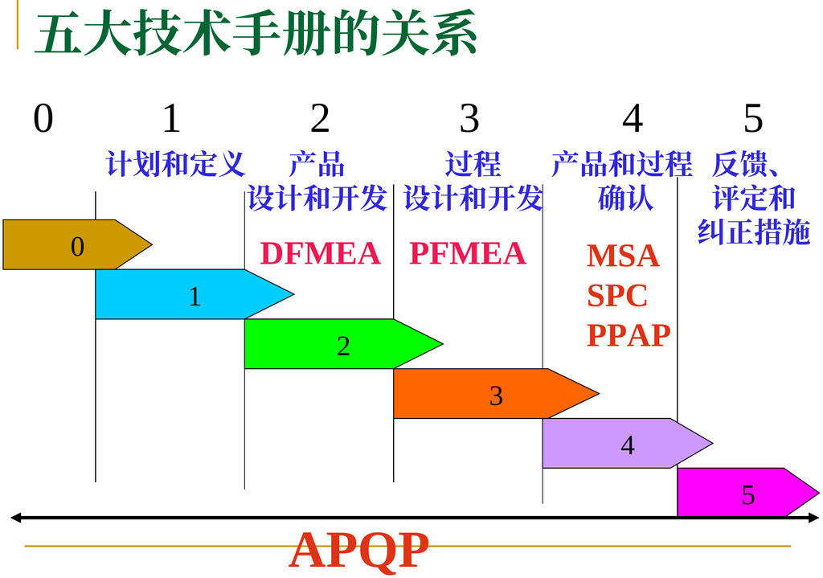

- 五大工具：APQP & CP、FMEA、MSA、SPC、PPAP——第 2 讲逐一展开

## 七项原则逐条（一）：顾客、领导、全员

> 上一页讲行业加严；这一页回答：9001 的前三条原则在现场怎么落地。

**原则不是口号：每一条都要落成“谁来做、做什么、做到什么程度”。**

| 原则 | 现场要求 | 制造实例 |
| --- | --- | --- |
| 1 以顾客为关注焦点 | 识别外部与内部顾客（下工序即顾客），把要求转成可测目标 | 顾客满意度 ≥95 分、零公里 PPM（百万分之缺陷数）≤50 |
| 2 领导作用 | 发布方针、统一方向、提供资源与授权、主持管理评审 | 质量方针“开放、创新、改进” |
| 3 全员参与 | 各级人员胜任、授权、参与改善 | 班组 QC（质量控制）小组与提案改善 |

- 三条组成一条责任链：顾客提要求、领导配资源、员工守标准，缺一不可。
- 内部顾客是全员参与的抓手：下工序的抱怨，就是本工序的质量问题。
- 领导作用的证据不是讲话，而是资源、授权与管理评审记录。

**记住：把三条原则翻译成“顾客指标、领导资源、员工标准”三张清单，才算真正落地。**

## 七项原则逐条（二）：过程、改进、循证、关系

**这四条各对应一种最常见的失败方式——每条原则都是一面“反例镜子”。**

| 原则 | 现场含义 | 常见反例 | 对应工具 |
| --- | --- | --- | --- |
| 4 过程方法 | 管输入输出，更管过程之间的接口 | 部门墙：接口处无人负责 | 过程链、SPC |
| 5 改进 | 持续改进是永恒目标 | 只做应急处置，不做再发防止 | PDCA、8D 的 D7 |
| 6 循证决策 | 用数据与事实说话，经验作补充 | 凭经验调参；数据本身不可信 | 检查表、MSA、SPC |
| 7 关系管理 | 与供方、合作伙伴等共赢 | 一味压价，供方降质 | 供应商开发、PPAP |

- 教材：每天进步 1%，一年就是约 37 倍——改进不在于大小，而在于坚持
- 教材谈关系管理：即使不能给供应商“吃肉”，也要给对方“一口汤喝”
- 循证决策的前提是数据可信——所以第 2 讲要先讲 MSA（测量系统分析）

## PDCA：四个阶段与八个步骤

**四阶段管方向、八步骤管动作：P 四步、D 一步、C 一步、A 两步。**

| 阶段 | 步骤 | 名称 | 做什么 |
| --- | --- | --- | --- |
| P 策划 | 1 | 找问题 | 用数据找出实际与目标的差距 |
| P | 2 | 查原因 | 用因果图、5Why 列出可能原因 |
| P | 3 | 找要因 | 用数据验证确定主因（最易跳过） |
| P | 4 | 定计划 | 5W1H 写清人、事、时、地与做法 |
| D 实施 | 5 | 执行 | 按计划落实对策 |
| C 检查 | 6 | 检查效果 | 用数据对比目标，验证有效性 |
| A 处置 | 7 | 总结经验 | 有效对策写进标准（最易跳过） |
| A | 8 | 提出新问题 | 遗留问题进入下一轮循环 |

- 课件另给“八分法”：目标、方法、条件、实施、结果、原因、应急处置、再发防止——与八步骤互为表里

## PDCA 的四个特点：循环、套环、上升、统计

**四个特点合起来是一句话：PDCA 是“把经验变成标准、再抬高标准”的机制。**

| 特点 | 含义 | 制造现场例子 |
| --- | --- | --- |
| 周而复始 | 四阶段不是做一次就完，一个循环接一个循环 | 一次 8D 关闭后，遗留问题开新一轮 |
| 大环带小环 | 公司级体系套部门、班组、供应商子循环 | 年度质量目标 → 车间月度改善 |
| 阶梯式上升 | 每循环一次，标准抬高一档 | Cpk 从 1.00 → 1.33 → 1.67 |
| 统计工具 | 用数据与统计方法找问题、验效果 | 排列图找问题，控制图验效果 |

- 没有阶梯式上升的循环只是“原地转圈”：标准不变，问题就会复发
- 统计工具是最容易被忽略的一条：没有数据，P 和 C 都变成拍脑袋
- 与 8D 的关系：8D 是 PDCA 在“客户投诉”场景下的一套固定写法（第 7 讲展开）

## 质量统计基础（一）：波动与分布

**质量特性一定在波动，但波动有规律——这正是统计学能进入质量管理的原因。**

- 波动来自人、机、料、法、环五个方面的微小差异，叠加后表现为数据离散
- 相同条件下的批量数据呈“中间多、两边少”：近似正态 $X\sim N(\mu,\sigma^2)$
- $\mu$ 决定位置、$\sigma$ 决定宽窄：$\pm1\sigma$ 68.27%、$\pm2\sigma$ 95.45%、$\pm3\sigma$ 99.73%
- 规格限 $USL$、$LSL$ 把分布切成合格区与两侧尾部，**缺陷率就是尾部面积**
- 统计质量管理的任务：用样本估计 $\mu$、$\sigma$，再对照规格作判断
- 教材：相同时间、地点、原材料、方法生产的大量产品，其质量服从统计规律

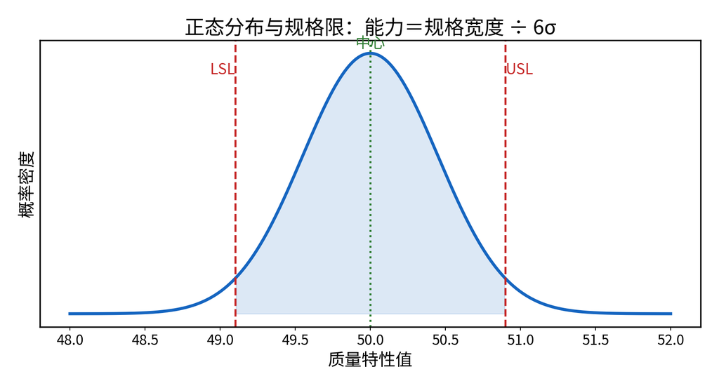

## 直方图读法：正常型、偏向型、双峰型、孤岛型

**先看形状、再对规格：形状异常先查数据来源，位置偏差才谈能力。**

| 型态 | 形状 | 常见原因 |
| --- | --- | --- |
| 正常型 | 中间高两边低 | 过程稳定，可算能力 |
| 偏向型 | 左右不对称 | 工具磨损、单侧剔除 |
| 双峰型 | 两个峰 | 两台设备／两批料混批 |
| 孤岛型 | 端部有小岛 | 混入异常品、测量错误 |

- 画图前提：至少 50 个数据，组数 $K$ 与组距 $C$ 要一致
- 判读顺序：**形状 → 分布宽度与规格宽度的关系 → 再算 $C_p$／$C_{pk}$**

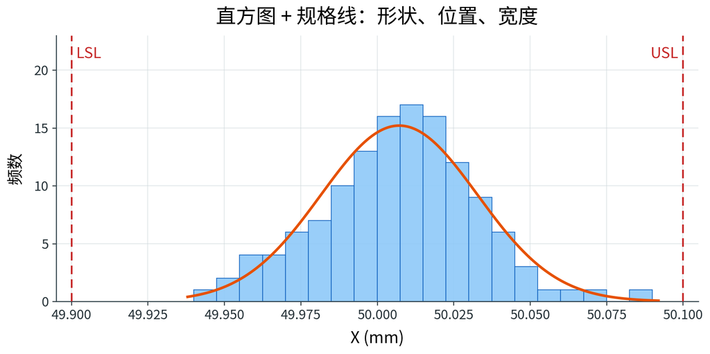

## 过程能力入门：Cp、Cpk 与 1.33／1.67 门槛

> 上一页看直方图对规格；这一页回答：过程能力怎么用一个指数判断。

公式

$$C_p=\frac{USL-LSL}{6\sigma},\qquad C_{pk}=\min\left(\frac{USL-\mu}{3\sigma},\ \frac{\mu-LSL}{3\sigma}\right)$$

符号：$USL$、$LSL$ 规格上／下限，$\mu$ 过程均值，$\sigma$ 过程标准差，$\bar X$ 样本均值，$C=(USL+LSL)/2$ 规格中心，$T=USL-LSL$ 公差带宽（以上均与特性同单位）；$C_p$、$C_{pk}$、$C_a$ 为无量纲指数。

- $C_p$ 量精度，只看波动大小；$C_{pk}$ 量能力，同时看中心位置与波动。
- 准度 $C_a=\dfrac{|\bar X-C|}{T/2}$，且 $C_{pk}=C_p(1-|C_a|)$——先分清是“偏心”还是“太散”。
- 两道门槛：$C_{pk}\ge1.33$ 是量产及格线，$C_{pk}\ge1.67$ 是关键／安全特性线。
- 分级判读、算例与 ppm 换算见第 2 讲，本讲只记门槛与含义。

**记住：$C_{pk}$ 同时罚偏心与波动——$C_p$ 再高，中心偏了 $C_{pk}$ 也低。**

## 控制图入门：3σ 控制限与判异

> 上一页判断过程能力够不够；这一页回答：运行中怎么监控、报警读什么。$CL$ 为中心线（过程均值），$\sigma$ 为过程标准差（同特性单位），控制限 $UCL/LCL=CL\pm3\sigma$。
- 横轴按时间排点、纵轴排特性值，点连成折线看趋势与异常。
- 控制限来自**过程本身**，规格限来自**顾客要求**，二者不能混用。
- $\pm3\sigma$ 内含 99.73%，1000 点约误报 2.7 点，出界即小概率事件。
- 常用判异三条：①点出界；②连 9 点同侧；③连 6 点单调升降。

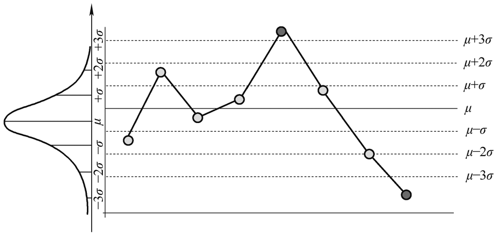

- 控制图只答“过程稳不稳”，查原因靠因果图与 5Why。
- 第 2 讲讲判异八准则，并算一张 $\bar X$–$R$ 控制图。

**记住：控制限来自过程、规格限来自顾客——混用是 SPC 最常犯的错误。**

## QC 七大手法：七个问题、七种图

> 上一页讲控制图怎么判异；这一页回答：什么问题该用哪张图。

| # | 手法 | 回答的问题 |
| --- | --- | --- |
| 1 | 检查表 | 数据怎么收、收什么 |
| 2 | 分层法 | 按人机料法环拆开分层 |
| 3 | 排列图 | 哪些问题最要紧（80/20：少数原因造成多数问题） |
| 4 | 因果图 | 原因可能有哪些（4M1E＝人、机、料、法、环） |
| 5 | 直方图 | 分布什么形状、离规格多远 |
| 6 | 散布图 | 两个因素相关吗 |
| 7 | 控制图 | 过程稳不稳 |

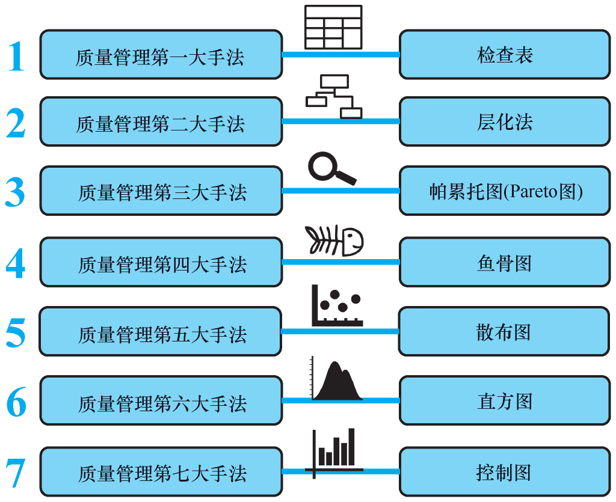

- 检查表、分层法、排列图、因果图、散布图在 P 阶段用；直方图与控制图在 C 阶段验证效果。
- 第 2 讲：每种图怎么画、怎么判读，以及它们在 8D 里的位置。

**记住：选图先问“我要回答什么问题”——是问题决定图，不是图决定问题。**

## 质量改进组织与标准化：让成果留下来

**改进的价值不在“解决了这次”，而在“下次不再发生”——标准化就是这道闸门。**

| 层级 | 组织 | 做什么 | 输出 |
| --- | --- | --- | --- |
| 决策 | 质量委员会 | 定目标、配资源、评审 | 质量方针与目标 |
| 管理 | 质量部门 | 建体系、内审、协调 | 体系文件、内审报告 |
| 执行 | QC 小组／跨职能小组 | 选题、查因、对策、验证 | 改善成果、标准修订 |

- QC 小组活动：选题 → 现状调查 → 原因分析 → 对策实施 → 效果确认 → 标准化
- 标准化要落到四处：作业指导书、控制计划、FMEA、设计规范——否则问题还会回来
- 与 8D 的 D7“预防再发生”、PDCA 的 A 阶段是同一件事：**把改进写进文件**
- 常见失败：只开会不验证、成果不入标准、换人又回到老做法

## 质量数据与测量：MSA 先说清“数据可不可信”

**测量系统分析（MSA）的用途只有一个：在相信一张能力报告之前，先证明生成它的数据本身可信。**

- 测量系统 = 仪器 + 人 + 方法 + 环境 + 软件；输入标准件与被测零件，输出“数值 + 判定”
- 误差五性：偏倚（准不准）、线性、稳定性、重复性、再现性
- 三档判读（可接受／有条件接受／不可接受）是能力判读的**准入证**

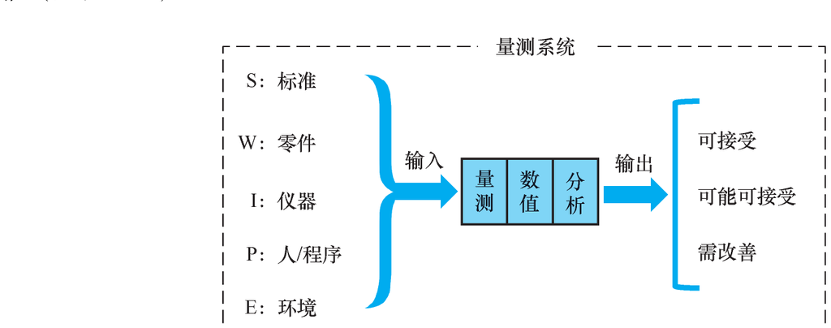

- 为什么重要：测量波动会混进过程波动，$C_{pk}$ 与判异结论都会失真
- 一句话：**先量准，再谈能力**——数据不可信，越精确越误导
- GR&R 算法与 10%／30% 判读见第 2 讲

## 过程能力与不良率换算：Cpk 到 ppm

换算公式（双侧、正态、受控）

$$p=2\Phi\left(-3C_{pk}\right)\times 10^{6}$$

[figure not shown]

- 结论：从 1.33 到 1.67，不良率从 66 ppm 降到 0.54 ppm，约两个数量级
- 前提：过程受控、近似正态、数据独立；不满足时改用 $P_{pk}$
- 换算表与推导见第 2 讲

## SPC 三个判读场景：出界、趋势、能力不足

**控制图只回答“有没有特殊原因”，能力指数回答“普通原因够不够小”——两问不能混。**

| 场景 | 图形信号 | 判据与处置 |
| --- | --- | --- |
| 一：点出界 | 单点落在 3σ 外，或连续 9 点在同侧 | 特殊原因，立即停线查 5M1E；先隔离这一段已产出的产品 |
| 二：趋势与周期 | 连续 6 点递增／递减、链状、周期性起伏 | 刀具磨损、模具温升、换批、班次差异；缩短采样间隔并预警 |
| 三：全在限内 | 无判异信号，但 $C_{pk}<1.33$ | 普通原因，属能力不足；改工艺、改设计，不是抓人 |

- 判读顺序：先判稳（控制图）→ 再判能力（$C_{pk}$）→ 再判责任（特殊原因归现场，普通原因归系统）
- 两个常见误判：拿规格限当控制限，把顾客要求当成过程自己的声音；一报警就调机，过度调整反而放大波动
- 一句话：**报警不等于事故，稳定也不等于合格**

## 抽样检验与 OC 曲线：两类风险与分辨力

**抽检不是“少检一点”，而是用样本推断批——必须说清两类错误各有多大。**

- 何时用抽检：批量大、检验成本高、破坏性检验；安全与关键特性宁可全检
- 两类风险：$\alpha$ 生产者风险（好批被拒，常取 5%）、$\beta$ 消费者风险（坏批被收，常取 10%）
- OC 曲线 $L(p)$：横轴批不合格率，纵轴接收概率；$n$ 越大曲线越陡、分辨力越强
- 抽样方案与算例见第 2 讲

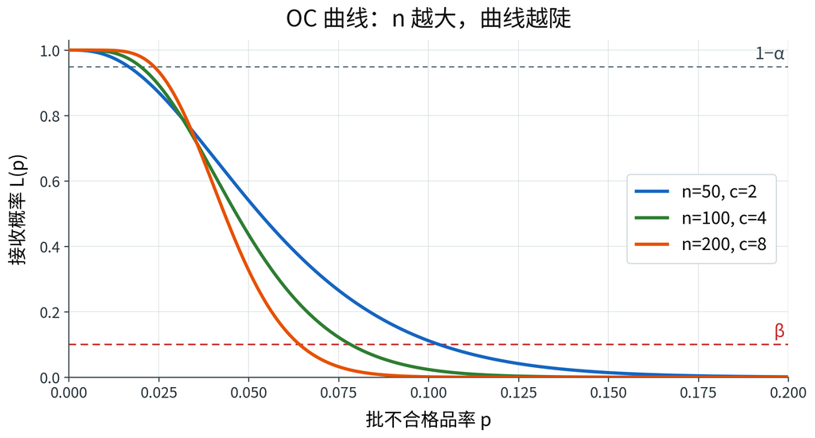

- 一句话：**抽样方案买的是分辨力，付的代价是样本量与风险**

## 质量成本决策实例：一笔防错投入该不该花

**决策不看“花了多少钱”，看“省下的损失是否大于投入”——两条判据：回收期、损失结构。**

| 项目 | 现状 | 投入后 | 口径 |
| --- | --- | --- | --- |
| 月不合格率 | 2.0% | 0.3% | 情景数据，用于课堂推演 |
| 月质量损失 | 6.0 万元 | 0.9 万元 | 10 万件 × 不合格率 × 30 元／件 |
| 月节省 | — | 5.1 万元 | 6.0 − 0.9 |
| 年净收益 | — | 56.2 万元 | 5.1 × 12 − 5.0（年维护） |
| 一次性投入 | 40 万元 | — | 防错装置与调试 |
| 静态回收期 | — | 约 8.5 个月 | 40 ÷ 56.2 × 12 |

- 判据一：回收期短于一年，且不挤占安全与环保预算，可以立项
- 判据二：损失结构要从“外部损失”转向“预防”——只降返工不降客诉，等于没改
- 陷阱：只算显性损失（返工工时），漏算隐性损失（客诉处理、召回、订单流失）
- 一句话：**质量投入不是成本，是买“损失不发生”**

## 质量改进八步：DMAIC 的落地版

**改进不是“开个会、抓个人”，而是一条有闸门的流水线：每一步都有输入、输出和放行条件。**

1. **选课题**（D）：从 CTQ、COPQ、客诉里挑，写清现状、目标、范围
2. **测现状**（M）：先确认基线与测量系统合格，再谈改进
3. **找原因**（A）：鱼骨图、FMEA、分层，先把候选列全
4. **验要因**（A）：用数据验证，不靠投票——最容易跳过的一步
5. **定对策**（I）：防错优先，其次探测；同步复核风险
6. **试运行**（I）：小批验证、前后对比，记录副作用
7. **标准化**（C）：文件、培训、控制计划一起更新
8. **固化复制**（C）：横向展开，财务确认收益
- 判据：没有闸门的改进只是活动——证据不齐，下一步不许开工
- 一句话：**改进的可靠性，取决于第 4 步有没有数据**

## 防错设计十原则：不给人犯错的机会

**防错强度分三级：做不错（断根、保险）＞ 做错立刻发现（自动、相符、顺序）＞ 做错不流出（隔离、复制、层别、警告、缓和）。**

1. **断根**：取消靠人判断的工步
2. **保险**：条件不满足就锁死，如双手按钮
3. **自动**：传感器替代人工确认与记录
4. **相符**：颜色／形状／扫码防混
5. **顺序**：规定次序，跳步即报警
6. **隔离**：不合格品专箱加锁
7. **复制**：双人复核、二次扫码
8. **层别**：三色卡区分待检／合格／不合格
9. **警告**：安灯与超差声光报警
10. **缓和**：防错装结构、限位缓冲
- 怎么判断：优先“做不错”，其次“立刻发现”，最后才靠“警告”；只靠培训与责任心不算防错
- 一句话：**最好的防错，是让新人也做不错**

## 供应商质量管理：从来料检验到二方审核

**供应商质量管理的目标不是“检出来”，而是“让他做对”——把控制点前移到供方的过程里。**

| 环节 | 做什么 | 判据 |
| --- | --- | --- |
| 准入 | 体系审核 + 样件认可（PPAP） | 体系证书有效，样件全尺寸与性能合格 |
| 分级 | 战略／优选／合格／限用 | 按 QCDS（质量、成本、交付、服务）打分 |
| 绩效 | 月度评分、年度评比 | 来料 PPM、批退率、8D 按期关闭率 |
| 改进 | 8D 跟踪、驻厂辅导、二方审核 | 不符合项关闭率、同类问题复发次数 |
| 退出 | 限用、减量、淘汰 | 连续不达标，或出现重大诚信问题 |

- 为什么：外购件往往占成本大头，而问题的源头常在二级、三级供应商
- 判据：来料检验只是最后一道筛子；真正的判据是“供方过程能力 + 变更是否申报”
- 一句话：**供应商的质量就是你的质量**

## 质量审核三类：第一方、第二方、第三方

**审核不是“挑毛病”，是用独立的眼睛回答三个问题：有没有按文件做、做了有没有用、问题有没有关掉。**

| 类型 | 谁审谁 | 主要目的 |
| --- | --- | --- |
| 第一方（内审） | 组织审自己 | 找体系漏洞，为管理评审提供输入 |
| 第二方 | 顾客审供方，或供方审上游 | 供应链准入与绩效验证 |
| 第三方 | 独立认证机构 | 认证与监督审核，向社会提供信任 |

- 三种对象：体系审核（文件与流程）、过程审核（工序能力与执行，如 VDA 6.3）、产品审核（成品实物）
- 三条判据：符合性、有效性、闭环——只查“有没有记录”是最低级的审核
- 不符合分级：严重不符合、一般不符合、观察项；严重项通常导致不推荐认证
- 常见失败：内审变“补记录”，管理评审不开，纠正措施只改现象不改原因
- 一句话：**审核的价值不在查出几条，而在关掉几条**

## 质量目标分解实例：从公司指标到班组

**目标分解不是把数字分下去，而是把“谁负责哪一段波动”分清楚。**

| 层级 | 指标示例 | 口径与数据源 |
| --- | --- | --- |
| 公司 | 客诉率、零公里 PPM | 售出 90 天内故障数 ÷ 销量，售后系统 |
| 部门 | 一次合格率 FPY、直通率 RTY | 不返工即合格的比例；RTY 为各工序 FPY 连乘 |
| 班组 | 工序合格率、首检执行率 | 按班次统计，每日公布 |
| 岗位 | 自检漏检率、参数记录完整率 | 抽检复核，每周统计 |

- 算例：三道工序 FPY 为 0.98、0.96、0.99，则 RTY ≈ 93.1%；靠返工把最终合格率修到 99%，损失已经发生
- 判据 SMART：可测量、有基线、有责任人、有时限，且不与交付指标打架
- 陷阱：只考结果不考过程，班组就会“藏不良”；指标超过五个，等于没有重点
- 一句话：**目标分解不是分数字，是分责任**

## 质量信息系统与追溯：把范围缩到最小

**QMS 管“判定与记录”，MES 管“过程数据”，ERP 管“物料批次”——追溯靠三者对齐。**

| 模块 | 装什么 | 判据 |
| --- | --- | --- |
| 文档控制 | 体系文件、作业指导书、版本与发放 | 现场用的是不是最新版 |
| 不合格品 | 隔离、评审、让步接收、报废 | 每一件都有去向与批准人 |
| CAPA | 纠正与预防措施、验证、关闭 | 关闭前有有效性验证 |
| 审核与培训 | 内审计划、不符合项、岗位资格 | 到期提醒，资格与岗位匹配 |

- 追溯两条路径：正向（原料批次 → 成品 → 客户）、反向（投诉 → 批次 → 原料与工序参数）
- 标识三件套：批号／序列号、时间戳、工位与设备号；缺一项就断链
- 判据：做一次追溯演练——能否在 1 小时内锁定受影响批次与客户清单
- 一句话：**追溯不是存数据，是出问题时能把范围缩到最小**

## 质量与可靠性衔接：出厂那一刻之后

**质量回答“出厂时符不符合规格”，可靠性回答“用三年还靠不靠得住”。**

- 定义：$R(t)=P(T>t)$，规定条件下、规定时间内完成规定功能的概率
- 指数分布：$R(t)=e^{-\lambda t}$，$MTBF=1/\lambda$；失效率 $\lambda$ 常用 FIT 表示
- 浴盆曲线三段与对策：早期失效（缺陷暴露）用筛选与老化；偶然失效（近似常数）用冗余与降额；耗损失效（老化磨损）用预防更换
- 怎么判断：对客户承诺用 $R(t)$、MTBF、B10 寿命，而不是“出厂合格率 99%”

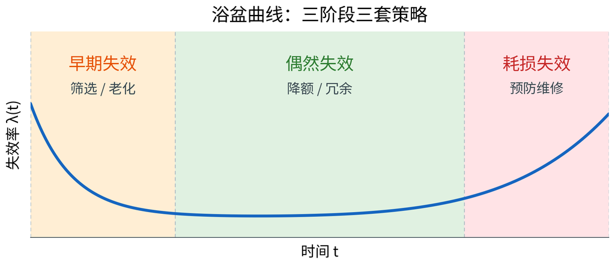

- 为什么必须衔接：检验只能抓“当下”，早期失效与耗损失效都发生在交付之后
- 一句话：**质量管“出门那一刻”，可靠性管“之后十年”**

## 缩写速查：标准、体系与质量指标

> 见缩写先还原英文全称，再看它管“组织”还是“产品”——这是判断体系归属最快的一步。

| 缩写 | 英文全称 | 中文 |
| --- | --- | --- |
| ISO | International Organization for Standardization | 国际标准化组织 |
| IEC | International Electrotechnical Commission | 国际电工委员会 |
| GB／GB/T | 国家标准／推荐性国家标准（T＝推荐） | 强制／自愿采用 |
| GJB | Guojia Junyong Biaozhun | 国家军用标准 |
| IDT／MOD／NEQ | Identical／Modified／Not Equivalent | 等同／修改／非等效采用 |
| CNAS／CMA | China National Accreditation Service／China Metrology Accreditation | 认可机构／检验检测资质认定 |
| 3C | China Compulsory Certification | 中国强制性产品认证 |
| HLS | High Level Structure | 管理体系高阶结构 |

| 缩写 | 英文全称 | 中文 |
| --- | --- | --- |
| QMS／EMS／OHSMS | Quality／Environmental／Occupational Health and Safety Management System | 质量／环境／职业健康安全管理体系 |
| EnMS／ISMS | Energy／Information Security Management System | 能源／信息安全管理体系 |
| IATF／AIAG | International Automotive Task Force／Automotive Industry Action Group | 国际汽车推动小组／美国汽车工业行动集团 |
| VDA | Verband der Automobilindustrie | 德国汽车工业协会 |
| TQM | Total Quality Management | 全面质量管理 |
| PDCA | Plan-Do-Check-Act | 策划—实施—检查—处置 |
| DMAIC | Define-Measure-Analyze-Improve-Control | 定义—测量—分析—改进—控制 |
| Cp／Cpk | Process Capability (Index) | 过程能力（指数） |

- 记法：只记“全称—中文—用在哪”；体系归属是单选高频——9001 质量、14001 环境、45001 职业健康安全

## 推导留给 AI：质量管理基础

- 用自己的话复述质量的五个关键要素，并各举一个制造现场的例子。
- 质量管理的五项活动中，哪一项最容易被企业忽视？为什么？
- 七项原则中“循证决策”与“改进”是什么关系？用 PDCA 说明。
- 查证 ISO 9001:2015 与 IATF 16949:2016 的关系与主要差异。
- 计算：若企业每年外部损失成本为 1000 万元，预防成本增加 50 万元可减少外部损失 30%，这笔投入是否值得？

# 第四部分 · 质量的社会责任与课程主线

- 质量事故的代价：凯悦酒店、波音 737 MAX
- 安全事故与安全责任事故
- 质量工具的社会意义与课程伦理主线
- **主线**：质量标准 → 社会责任 → 伦理决策
- **承上**：上一部分讲质量的定义与体系；本部分要回答“质量失败的代价由谁承担、责任怎么判定”。

## 课堂讨论：如果你是质量工程师

**情境**：某批产品在出厂检验中发现一项参数接近上限但未超差。生产部门希望放行，因为订单紧急、返工成本高；**客户尚不知情，只催交期**。

**讨论问题**

1. 放行的技术依据是什么？需要哪些数据支撑？
2. 如果放行后出现批量失效，责任如何划分？
3. 作为质量工程师，你会怎么做？需要向谁报告？
4. 这个情境中，“顾客要求”与“隐含需求”分别是什么？

> 提示：用本讲的“安全事故 vs 安全责任事故”“循证决策（七项原则之一）”和“可预见性”三个工具来分析。

## 质量的社会契约：企业以质量换市场信任

- 质量不只是“符合规格”，而是企业向社会作出的一项**可验证的承诺**
- 企业一侧的承诺：符合法规与标准、如实告知风险、持续改进、出问题担责
- 社会一侧的回报：市场准入、品牌溢价、顾客复购、监管信任
- 契约的三条“违约线”：隐瞒缺陷、擅自变更、把风险转嫁给不知情者
- 三条履约机制：**质量成本**算清代价、**质量体系**写清流程、**质量文化**让坏消息能上传
- 契约的特点：平时看不见，出事时它就是全部——凯悦案里“盖了章的图纸”就是契约的凭证
- 一句话：顾客用钱投票，社会用安全投票

## 缺陷代价的四个承担者

| 承担者 | 直接代价 | 被追究的方式 | 代价的可逆性 |
| --- | --- | --- | --- |
| 顾客 | 伤亡、财产损失、时间与信任 | 索赔、诉讼、舆论 | 不可逆：伤害无法用赔偿还原 |
| 企业 | 召回、停产、罚款、订单流失 | 民事赔偿、行政处罚、刑事追责 | 部分可逆：钱能补，品牌难补 |
| 工程师 | 执照、职业声誉、法律责任 | 纪律裁决、吊销执照、刑罚 | 很难逆：职业生命可能终止 |
| 社会 | 公共安全、环境、制度成本 | 立法、标准修订、监管改革 | 长期：靠制度慢慢修复 |

- 代价会沿链条**转嫁**：企业赔得起，顾客的命赔不回
- 最不公平的是：承担伤害的人往往最难举证
- 工程伦理的作用：把“看不见的第四方”纳入设计决策

## 判定安全责任事故：预见、告知、检查、纠正

- **安全事故**：造成人员伤亡或财产损失的事件；按责任性质分**责任事故**与**非责任事故**
- **安全责任事故**：责任主体存在“应尽而未尽的注意义务”，并与损害有因果关系
- 四要件是递进关系，缺一环都不能直接判定责任：

| 义务 | 法理含义 | 凯悦案中的对应 | 举证要点 |
| --- | --- | --- | --- |
| 预见义务 | 应预见而未预见可预见的后果 | 两根吊杆使荷载翻倍 | 专业常识能否预见 |
| 告知义务 | 应把风险告知相关方 | 变更未书面通知设计方 | 有无书面记录与回执 |
| 检查义务 | 应对图纸、现场、前兆进行检查 | 未做图纸最终检查 | 有无复核签字 |
| 纠正义务 | 发现风险后应采取措施 | 屋顶坍塌后未全面调查 | 有无整改记录 |

- 反例：因技术局限、不可抗力导致的损害属**非责任事故**——不是“无人负责”，而是“责任不在个体”
- 一句话：判定责任的不是“后果多严重”，而是“义务有没有、做到没做到、做到了能不能拦住”

## 责任事故的判定流程：规范→义务→因果→责任

判定不是“找替罪羊”，而是一条可以复核的证据链：

| 步骤 | 要回答的问题 | 需要的证据 |
| --- | --- | --- |
| ① 查规范 | 法律、标准、合同、行业惯例要求了什么？ | 规范条文、合同条款、图纸说明 |
| ② 定义务 | 谁在什么时点负什么义务？ | 岗位职责、签章记录、审批流程 |
| ③ 查因果 | 未履行义务与损害之间有无实质联系？ | 计算书、试验报告、时间线 |
| ④ 定责任 | 法律、纪律、伦理三层责任如何分配？ | 判决书、纪律裁决、伦理分析 |

- 以凯悦案走一遍：建筑规范 → 设计方最终检查义务 → 未复核与坍塌的因果 → 严重疏忽
- 三层责任可以分离：法律赔钱、纪律吊照、伦理失范，未必同时成立
- 常见错误：跳过“规范”直接讲道德，或用“结果严重”倒推“责任重大”
- 一句话：判定的终点不是“谁错了”，而是“**哪一环本可拦住**”

## 凯悦案（一）：事故背景与酒店结构

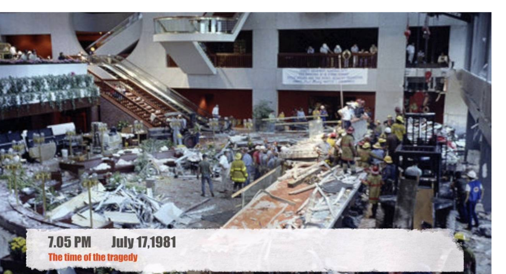

- **1981 年 7 月 17 日 19:05**，美国密苏里州堪萨斯城皇冠中心凯悦酒店中庭
- 中庭正在举行**茶舞会**，人群密集；中庭上方有 2、3、4 层三段**悬挂式天桥**
- 结构：天桥自重与人群活载，经箱梁与连接节点传给吊杆，吊杆再挂到屋顶钢桁架
- 事故：4 层天桥先断，砸向正下方的 2 层天桥，两层一起坠入中庭
- 伤亡：**114 人死亡、216 人受伤**；调查报道获普利策奖，事故细节被完整公开
- 照片中仍有一段天桥悬在半空：说明问题不在整体结构，而在**局部连接**

## 凯悦天桥的结构：一根吊杆变两根

[figure not shown]

## 凯悦案（二）：吊杆连接的设计变更

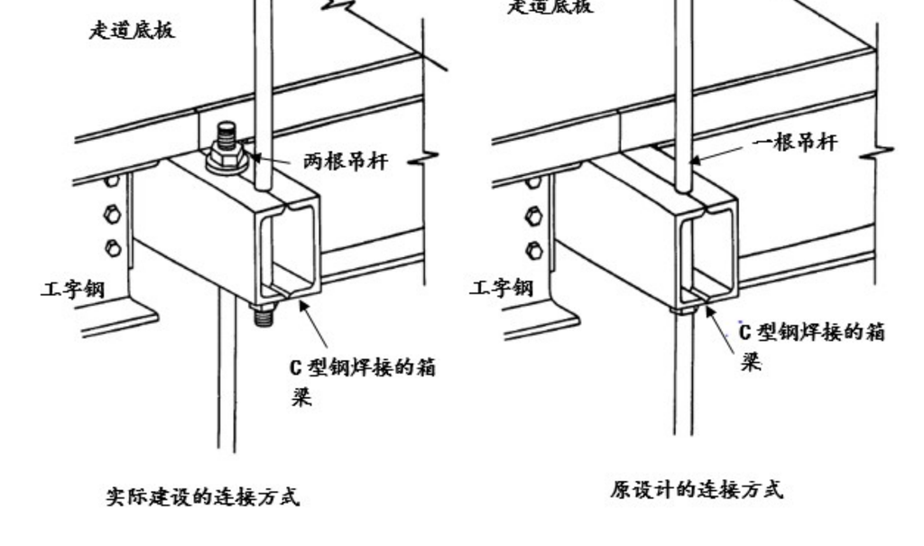

- **原设计**（右）：一根通长吊杆从屋顶穿过 4 层箱梁，再下挂 2 层天桥——每个节点只承担一层荷载
- **实际建造**（左）：改为两根吊杆，4 层、2 层各一根——省去长吊杆穿两层天桥的施工麻烦
- 变更的后果：2 层天桥吊在 4 层天桥下方，4 层连接节点必须**托住两层天桥**
- 定量：原设计每节点约 **89 kN**；变更后 **178 kN**；节点承载力约 **133 kN**
- 安全系数：$K_1=133/89=1.49$；$K_2=133/178=0.75<1$
- 结论：不是“余量变小”，而是“在设计荷载下**必然破坏**”；维持原安全水平需 **267 kN**

## 凯悦案（三）：受力与失效链

- 传力路径：人群活载 → 天桥箱梁 → 连接节点 → 吊杆 → 屋顶钢桁架
- 破坏点在 4 层天桥与吊杆连接的**箱梁腹板**：螺母的集中力把腹板局部压坏、撕裂
- 节点失效后，原本由它承担的荷载瞬间**重分配到相邻节点**
- 相邻节点没有为“替邻居扛荷载”留余量，于是接连失效——这就是**连续倒塌**
- 失效顺序可以还原：4 层先断 → 冲击 2 层 → 两层一起坠落
- 连续倒塌的条件：结构几乎没有冗余、没有第二条传力路径、活载已接近设计值
- 一句话：不是一个点坏了，而是“**没有第二个点能接住**”

## 凯悦案（四）：1979 年的屋顶坍塌前兆

- **1979 年 10 月 14 日**，仍在施工的中庭屋顶发生坍塌，面积超过 **250 m²**
- 事故前 **21 个月**——这是制度给出的一次明确警报
- 业主另聘独立结构公司 Seiden Page 调查，结论指向屋顶荷载，由 Gillum 更正设计
- 但委托范围**只限于屋顶**，不包括中庭天桥——一次“局部体检”放过了整栋楼
- G.C.E. 曾**三次**要求在现场设设计代表，均因成本控制被业主拒绝
- 若那次调查覆盖全楼，或现场有设计代表，连接处的变更很可能被发现
- 一句话：忽略前兆，等于把“偶然”变成“必然”

## 凯悦案（五）：法庭上的两个关键事实

- **事实一 · 电话**：Havens 称就设计变更电话通知并获 G.C.E. 同意；G.C.E. 在长达 **26 周**的庭审中始终否认收到电话
- 但变更后的图纸上，盖着 G.C.E. 的**印章**——1981 年，印章就是法律上的签字
- **事实二 · 前兆**：1979 年屋顶坍塌后，G.C.E. 没有进行应有的详尽调查
- 法庭认定：天桥设计不满足建筑规范；设计阶段未尽应尽责任；对已知前兆未追查
- 法庭同时认定：Havens 未尽责审核与标注变更——但最终仍判 **G.C.E. 对变更负责**
- 责任分配的逻辑：谁有**最终把关权**，谁承担最终责任
- 一句话：**口头同意不构成技术依据，签章即责任**

## 凯悦案（六）：责任判定与制度变化

- **纪律裁决（1985 年 11 月）**：Duncan、Gillum 与 G.C.E. 被判**严重疏忽**（gross negligence）
- 处罚：两名工程师失去密苏里州执照；G.C.E. 被剥夺工程公司资质；民事赔偿约 **1.4 亿美元**
- 判据升级：美国土木工程师协会（ASCE）通过政策明确“**结构工程师对设计项目负全部责任**”
- 制度落地：1990 年代以来各州与行业逐步推行**结构工程师负责人（SER）制度**——责任随签章走
- 四条制度遗产：变更控制、现场设计代表、全结构独立审查、签字盖章责任
- 对智能制造的映射：工程变更单（ECN）、设计评审、FMEA 探测度、MES 变更追溯
- 一句话：制度是把个人的一次侥幸，变成组织的一次**必查**

## 凯悦案（七）：五个“本可拦截”的节点

| 节点 | 本可做什么 | 谁负责 | 若拦住的结果 |
| --- | --- | --- | --- |
| 变更 | 变更单 + 重新计算 | Havens 提出、G.C.E. 批准 | 发现荷载翻倍 |
| 复核 | 独立复核连接处 | G.C.E. 设计团队 | 安全系数回到 1.5 |
| 审查 | 全结构独立审查 | 业主委托的第三方 | 发现其他薄弱连接 |
| 沟通 | 书面确认 + 图纸标注 | G.C.E. 与 Havens | 消除“电话之争” |
| 前兆 | 1979 年坍塌后全面调查 | 业主 + G.C.E. | 提前 21 个月排除隐患 |

- 五个节点都不贵，甚至只是“多算一遍、多问一句、多留一份记录”
- 事故不是一次错误，而是**五次没拦住**；防事故靠“任一节点有效”，不靠“人人都不出错”
- 一句话：**安全是冗余的函数**——多一道检查，就多一次活下来的机会

## 737 MAX（一）：两起事故的时间线

| 时间 | 事件 | 关键数据 |
| --- | --- | --- |
| 2018-10-29 | 狮航 JT610 起飞后坠海 | **189 人**遇难 |
| 2019-03-10 | 埃塞俄比亚航空 ET302 起飞后坠毁 | **157 人**遇难 |
| 2019-03-13 | 全球停飞 737 MAX | 停飞约 **20 个月** |
| 2020-01 | 波音暂停 737 MAX 生产 | 供应链与就业受冲击 |
| 2020-11 | 完成适航整改，FAA 批准复飞 | 复飞附带新训练要求 |
| 2021-01 | 与美国司法部达成和解 | 约 **25 亿美元** |

- 两起事故间隔仅 **132 天**，同一机型、同一系统、同一失效模式
- 共 **346 人**遇难——这不是软件 bug，而是系统工程与责任体系的失效

## 737 MAX（二）：MCAS 与单一传感器依赖

- **MCAS**（机动特性增强系统）：大迎角时自动压低机头，弥补大发动机前移带来的气动变化
- 触发条件：襟翼收起、自动驾驶关闭、迎角超过阈值；动作是自动配平**水平安定面**
- 缺陷一：**单一迎角传感器**——左右两侧轮流作为数据源，坏的一侧赶上就全错
- 缺陷二：**飞行员不知道 MCAS 存在**——训练材料未提及，手册没有专门程序
- 缺陷三：**与飞行员抢操纵**——自动配平反复介入，人工修正被覆盖
- 结果：单点数据 + 隐藏逻辑 + 无告警 = 把可恢复故障变成不可恢复
- 一句话：**冗余不是成本，是把“单点故障”变成“可生存故障”的唯一办法**